# HW4_TS_KatieBaerveldt

### *a. Fit a harmonic regression with trend to the data. Experiment with changing the number Fourier terms. Plot the observed gasoline and fitted values and comment on what you see.*

Since this series has long seasonal periods, it makes sense to use harmonic regression:

```r
fourier.gasoline.k2 <- tslm(gasoline.data ~ trend + fourier(gasoline.data, K=2))
#when I tested this on my window data, the adjusted R squared actually went down
summary(fourier.gasoline.k2)
```

```
##
## Call:
## tslm(formula = gasoline.data ~ trend + fourier(gasoline.data,
##     K = 2))
##
## Residuals:
##      Min       1Q   Median       3Q      Max
## -0.93267 -0.19216  0.00369  0.20962  1.00962
##
## Coefficients:
##                                      Estimate Std. Error t value Pr(>|t|)
## (Intercept)                         7.100e+00  2.237e-02 317.443  < 2e-16
## trend                               2.778e-03  5.719e-05  48.579  < 2e-16
## fourier(gasoline.data, K = 2)S1-52 -3.644e-02  1.581e-02  -2.305  0.02146
## fourier(gasoline.data, K = 2)C1-52 -2.730e-01  1.576e-02 -17.326  < 2e-16
## fourier(gasoline.data, K = 2)S2-52 -4.606e-02  1.579e-02  -2.918  0.00365
## fourier(gasoline.data, K = 2)C2-52 -6.915e-03  1.576e-02  -0.439  0.66099
##
## (Intercept)                        ***
## trend                              ***
## fourier(gasoline.data, K = 2)S1-52 *
## fourier(gasoline.data, K = 2)C1-52 ***
## fourier(gasoline.data, K = 2)S2-52 **
## fourier(gasoline.data, K = 2)C2-52
## ---
## Signif. codes:  0 '***' 0.001 '**' 0.01 '*' 0.05 '.' 0.1 ' ' 1
##
## Residual standard error: 0.2902 on 671 degrees of freedom
## Multiple R-squared:  0.8006, Adjusted R-squared:  0.7991
## F-statistic: 538.8 on 5 and 671 DF,  p-value: < 2.2e-16
```

My Adjusted R squared is 0.7991, so I’m going to attempt running a few different k values to see how many sin/cosine pairs seem optimal:

```r
fourier.gasoline.k3 <- tslm(gasoline.data ~ trend + fourier(gasoline.data, K=3))
summary(fourier.gasoline.k3)
```

```
##
## Call:
## tslm(formula = gasoline.data ~ trend + fourier(gasoline.data,
##     K = 3))
##
## Residuals:
##     Min      1Q  Median      3Q     Max
## -0.8363 -0.1837  0.0011  0.1989  0.9174
##
## Coefficients:
##                                      Estimate Std. Error t value Pr(>|t|)
## (Intercept)                         7.099e+00  2.176e-02 326.314  < 2e-16
## trend                               2.780e-03  5.563e-05  49.963  < 2e-16
## fourier(gasoline.data, K = 3)S1-52 -3.639e-02  1.538e-02  -2.366  0.01825
## fourier(gasoline.data, K = 3)C1-52 -2.728e-01  1.533e-02 -17.795  < 2e-16
## fourier(gasoline.data, K = 3)S2-52 -4.598e-02  1.536e-02  -2.995  0.00285
## fourier(gasoline.data, K = 3)C2-52 -6.646e-03  1.533e-02  -0.434  0.66473
## fourier(gasoline.data, K = 3)S3-52 -1.469e-02  1.535e-02  -0.957  0.33892
## fourier(gasoline.data, K = 3)C3-52 -9.621e-02  1.533e-02  -6.275 6.27e-10
##
## (Intercept)                        ***
## trend                              ***
## fourier(gasoline.data, K = 3)S1-52 *
## fourier(gasoline.data, K = 3)C1-52 ***
## fourier(gasoline.data, K = 3)S2-52 **
## fourier(gasoline.data, K = 3)C2-52
## fourier(gasoline.data, K = 3)S3-52
## fourier(gasoline.data, K = 3)C3-52 ***
## ---
## Signif. codes:  0 '***' 0.001 '**' 0.01 '*' 0.05 '.' 0.1 ' ' 1
##
## Residual standard error: 0.2822 on 669 degrees of freedom
## Multiple R-squared:  0.8119, Adjusted R-squared:   0.81
## F-statistic: 412.6 on 7 and 669 DF,  p-value: < 2.2e-16
```

```r
fourier.gasoline.k4 <- tslm(gasoline.data ~ trend + fourier(gasoline.data, K=4))
summary(fourier.gasoline.k4)
```

```
##
## Call:
## tslm(formula = gasoline.data ~ trend + fourier(gasoline.data,
##     K = 4))
##
## Residuals:
##      Min       1Q   Median       3Q      Max
## -0.85151 -0.17751  0.00061  0.19947  0.91935
##
## Coefficients:
##                                      Estimate Std. Error t value Pr(>|t|)
## (Intercept)                         7.099e+00  2.169e-02 327.255  < 2e-16
## trend                               2.780e-03  5.547e-05  50.122  < 2e-16
## fourier(gasoline.data, K = 4)S1-52 -3.636e-02  1.533e-02  -2.372  0.01799
## fourier(gasoline.data, K = 4)C1-52 -2.727e-01  1.528e-02 -17.842  < 2e-16
## fourier(gasoline.data, K = 4)S2-52 -4.595e-02  1.531e-02  -3.002  0.00279
## fourier(gasoline.data, K = 4)C2-52 -6.550e-03  1.528e-02  -0.429  0.66836
## fourier(gasoline.data, K = 4)S3-52 -1.465e-02  1.530e-02  -0.957  0.33879
## fourier(gasoline.data, K = 4)C3-52 -9.611e-02  1.529e-02  -6.288 5.81e-10
## fourier(gasoline.data, K = 4)S4-52 -2.606e-03  1.530e-02  -0.170  0.86480
## fourier(gasoline.data, K = 4)C4-52 -3.739e-02  1.529e-02  -2.446  0.01470
##
## (Intercept)                        ***
## trend                              ***
## fourier(gasoline.data, K = 4)S1-52 *
## fourier(gasoline.data, K = 4)C1-52 ***
## fourier(gasoline.data, K = 4)S2-52 **
## fourier(gasoline.data, K = 4)C2-52
## fourier(gasoline.data, K = 4)S3-52
## fourier(gasoline.data, K = 4)C3-52 ***
## fourier(gasoline.data, K = 4)S4-52
## fourier(gasoline.data, K = 4)C4-52 *
## ---
## Signif. codes:  0 '***' 0.001 '**' 0.01 '*' 0.05 '.' 0.1 ' ' 1
##
## Residual standard error: 0.2814 on 667 degrees of freedom
## Multiple R-squared:  0.8136, Adjusted R-squared:  0.8111
## F-statistic: 323.5 on 9 and 667 DF,  p-value: < 2.2e-16
```

```r
fourier.gasoline.k5 <- tslm(gasoline.data ~ trend + fourier(gasoline.data, K=5))
summary(fourier.gasoline.k5)
```

```
##
## Call:
## tslm(formula = gasoline.data ~ trend + fourier(gasoline.data,
##     K = 5))
##
## Residuals:
##      Min       1Q   Median       3Q      Max
## -0.85434 -0.18554  0.00095  0.19456  0.94954
##
## Coefficients:
##                                      Estimate Std. Error t value Pr(>|t|)
## (Intercept)                         7.099e+00  2.156e-02 329.278  < 2e-16
## trend                               2.780e-03  5.513e-05  50.428  < 2e-16
## fourier(gasoline.data, K = 5)S1-52 -3.635e-02  1.524e-02  -2.386  0.01733
## fourier(gasoline.data, K = 5)C1-52 -2.725e-01  1.519e-02 -17.944  < 2e-16
## fourier(gasoline.data, K = 5)S2-52 -4.592e-02  1.521e-02  -3.018  0.00264
## fourier(gasoline.data, K = 5)C2-52 -6.412e-03  1.519e-02  -0.422  0.67305
## fourier(gasoline.data, K = 5)S3-52 -1.460e-02  1.521e-02  -0.960  0.33744
## fourier(gasoline.data, K = 5)C3-52 -9.598e-02  1.519e-02  -6.318 4.84e-10
## fourier(gasoline.data, K = 5)S4-52 -2.541e-03  1.521e-02  -0.167  0.86736
## fourier(gasoline.data, K = 5)C4-52 -3.727e-02  1.519e-02  -2.453  0.01443
## fourier(gasoline.data, K = 5)S5-52 -3.014e-02  1.520e-02  -1.982  0.04785
## fourier(gasoline.data, K = 5)C5-52 -3.838e-02  1.519e-02  -2.526  0.01178
##
## (Intercept)                        ***
## trend                              ***
## fourier(gasoline.data, K = 5)S1-52 *
## fourier(gasoline.data, K = 5)C1-52 ***
## fourier(gasoline.data, K = 5)S2-52 **
## fourier(gasoline.data, K = 5)C2-52
## fourier(gasoline.data, K = 5)S3-52
## fourier(gasoline.data, K = 5)C3-52 ***
## fourier(gasoline.data, K = 5)S4-52
## fourier(gasoline.data, K = 5)C4-52 *
## fourier(gasoline.data, K = 5)S5-52 *
## fourier(gasoline.data, K = 5)C5-52 *
## ---
## Signif. codes:  0 '***' 0.001 '**' 0.01 '*' 0.05 '.' 0.1 ' ' 1
##
## Residual standard error: 0.2796 on 665 degrees of freedom
## Multiple R-squared:  0.8165, Adjusted R-squared:  0.8134
## F-statistic: 268.9 on 11 and 665 DF,  p-value: < 2.2e-16
```

```r
fourier.gasoline.k6 <- tslm(gasoline.data ~ trend + fourier(gasoline.data, K=6))
summary(fourier.gasoline.k6)
```

```
##
## Call:
## tslm(formula = gasoline.data ~ trend + fourier(gasoline.data,
##     K = 6))
##
## Residuals:
##      Min       1Q   Median       3Q      Max
## -0.81971 -0.18194  0.00699  0.17961  0.99079
##
## Coefficients:
##                                      Estimate Std. Error t value Pr(>|t|)
## (Intercept)                         7.0986938  0.0212338 334.310  < 2e-16
## trend                               0.0027819  0.0000543  51.231  < 2e-16
## fourier(gasoline.data, K = 6)S1-52 -0.0363010  0.0150053  -2.419  0.01582
## fourier(gasoline.data, K = 6)C1-52 -0.2723811  0.0149581 -18.210  < 2e-16
## fourier(gasoline.data, K = 6)S2-52 -0.0458687  0.0149842  -3.061  0.00229
## fourier(gasoline.data, K = 6)C2-52 -0.0062628  0.0149590  -0.419  0.67560
## fourier(gasoline.data, K = 6)S3-52 -0.0145361  0.0149790  -0.970  0.33219
## fourier(gasoline.data, K = 6)C3-52 -0.0958356  0.0149605  -6.406 2.83e-10
## fourier(gasoline.data, K = 6)S4-52 -0.0024618  0.0149757  -0.164  0.86948
## fourier(gasoline.data, K = 6)C4-52 -0.0371299  0.0149624  -2.482  0.01333
## fourier(gasoline.data, K = 6)S5-52 -0.0300452  0.0149728  -2.007  0.04519
## fourier(gasoline.data, K = 6)C5-52 -0.0382494  0.0149647  -2.556  0.01081
## fourier(gasoline.data, K = 6)S6-52 -0.0010361  0.0149700  -0.069  0.94484
## fourier(gasoline.data, K = 6)C6-52 -0.0711738  0.0149673  -4.755 2.43e-06
##
## (Intercept)                        ***
## trend                              ***
## fourier(gasoline.data, K = 6)S1-52 *
## fourier(gasoline.data, K = 6)C1-52 ***
## fourier(gasoline.data, K = 6)S2-52 **
## fourier(gasoline.data, K = 6)C2-52
## fourier(gasoline.data, K = 6)S3-52
## fourier(gasoline.data, K = 6)C3-52 ***
## fourier(gasoline.data, K = 6)S4-52
## fourier(gasoline.data, K = 6)C4-52 *
## fourier(gasoline.data, K = 6)S5-52 *
## fourier(gasoline.data, K = 6)C5-52 *
## fourier(gasoline.data, K = 6)S6-52
## fourier(gasoline.data, K = 6)C6-52 ***
## ---
## Signif. codes:  0 '***' 0.001 '**' 0.01 '*' 0.05 '.' 0.1 ' ' 1
##
## Residual standard error: 0.2754 on 663 degrees of freedom
## Multiple R-squared:  0.8225, Adjusted R-squared:  0.819
## F-statistic: 236.3 on 13 and 663 DF,  p-value: < 2.2e-16
```

```r
fourier.gasoline.k7 <- tslm(gasoline.data ~ trend + fourier(gasoline.data, K=7))
summary(fourier.gasoline.k7)
```

```
##
## Call:
## tslm(formula = gasoline.data ~ trend + fourier(gasoline.data,
##     K = 7))
##
## Residuals:
##     Min      1Q  Median      3Q     Max
## -0.8618 -0.1833  0.0073  0.1818  0.9528
##
## Coefficients:
##                                      Estimate Std. Error t value Pr(>|t|)
## (Intercept)                         7.098e+00  2.113e-02 335.982  < 2e-16
## trend                               2.783e-03  5.403e-05  51.506  < 2e-16
## fourier(gasoline.data, K = 7)S1-52 -3.630e-02  1.493e-02  -2.431  0.01531
## fourier(gasoline.data, K = 7)C1-52 -2.725e-01  1.488e-02 -18.308  < 2e-16
## fourier(gasoline.data, K = 7)S2-52 -4.588e-02  1.491e-02  -3.078  0.00217
## fourier(gasoline.data, K = 7)C2-52 -6.351e-03  1.488e-02  -0.427  0.66971
## fourier(gasoline.data, K = 7)S3-52 -1.456e-02  1.490e-02  -0.977  0.32885
## fourier(gasoline.data, K = 7)C3-52 -9.592e-02  1.489e-02  -6.444 2.24e-10
## fourier(gasoline.data, K = 7)S4-52 -2.500e-03  1.490e-02  -0.168  0.86681
## fourier(gasoline.data, K = 7)C4-52 -3.721e-02  1.489e-02  -2.500  0.01268
## fourier(gasoline.data, K = 7)S5-52 -3.009e-02  1.490e-02  -2.020  0.04378
## fourier(gasoline.data, K = 7)C5-52 -3.832e-02  1.489e-02  -2.574  0.01027
## fourier(gasoline.data, K = 7)S6-52 -1.093e-03  1.489e-02  -0.073  0.94150
## fourier(gasoline.data, K = 7)C6-52 -7.124e-02  1.489e-02  -4.784 2.12e-06
## fourier(gasoline.data, K = 7)S7-52  4.393e-02  1.489e-02   2.950  0.00329
## fourier(gasoline.data, K = 7)C7-52 -3.204e-03  1.489e-02  -0.215  0.82972
##
## (Intercept)                        ***
## trend                              ***
## fourier(gasoline.data, K = 7)S1-52 *
## fourier(gasoline.data, K = 7)C1-52 ***
## fourier(gasoline.data, K = 7)S2-52 **
## fourier(gasoline.data, K = 7)C2-52
## fourier(gasoline.data, K = 7)S3-52
## fourier(gasoline.data, K = 7)C3-52 ***
## fourier(gasoline.data, K = 7)S4-52
## fourier(gasoline.data, K = 7)C4-52 *
## fourier(gasoline.data, K = 7)S5-52 *
## fourier(gasoline.data, K = 7)C5-52 *
## fourier(gasoline.data, K = 7)S6-52
## fourier(gasoline.data, K = 7)C6-52 ***
## fourier(gasoline.data, K = 7)S7-52 **
## fourier(gasoline.data, K = 7)C7-52
## ---
## Signif. codes:  0 '***' 0.001 '**' 0.01 '*' 0.05 '.' 0.1 ' ' 1
##
## Residual standard error: 0.274 on 661 degrees of freedom
## Multiple R-squared:  0.8248, Adjusted R-squared:  0.8209
## F-statistic: 207.5 on 15 and 661 DF,  p-value: < 2.2e-16
```

```r
fourier.gasoline.k8 <- tslm(gasoline.data ~ trend + fourier(gasoline.data, K=8))
summary(fourier.gasoline.k8)
```

```
##
## Call:
## tslm(formula = gasoline.data ~ trend + fourier(gasoline.data,
##     K = 8))
##
## Residuals:
##      Min       1Q   Median       3Q      Max
## -0.85069 -0.18165  0.00736  0.17955  0.95619
##
## Coefficients:
##                                      Estimate Std. Error t value Pr(>|t|)
## (Intercept)                         7.098e+00  2.113e-02 335.953  < 2e-16
## trend                               2.783e-03  5.403e-05  51.509  < 2e-16
## fourier(gasoline.data, K = 8)S1-52 -3.630e-02  1.493e-02  -2.431  0.01532
## fourier(gasoline.data, K = 8)C1-52 -2.725e-01  1.488e-02 -18.310  < 2e-16
## fourier(gasoline.data, K = 8)S2-52 -4.589e-02  1.491e-02  -3.078  0.00217
## fourier(gasoline.data, K = 8)C2-52 -6.397e-03  1.488e-02  -0.430  0.66749
## fourier(gasoline.data, K = 8)S3-52 -1.458e-02  1.490e-02  -0.978  0.32838
## fourier(gasoline.data, K = 8)C3-52 -9.596e-02  1.489e-02  -6.447 2.21e-10
## fourier(gasoline.data, K = 8)S4-52 -2.520e-03  1.490e-02  -0.169  0.86574
## fourier(gasoline.data, K = 8)C4-52 -3.725e-02  1.489e-02  -2.502  0.01258
## fourier(gasoline.data, K = 8)S5-52 -3.012e-02  1.490e-02  -2.022  0.04361
## fourier(gasoline.data, K = 8)C5-52 -3.836e-02  1.489e-02  -2.576  0.01020
## fourier(gasoline.data, K = 8)S6-52 -1.124e-03  1.490e-02  -0.075  0.93989
## fourier(gasoline.data, K = 8)C6-52 -7.128e-02  1.489e-02  -4.786 2.10e-06
## fourier(gasoline.data, K = 8)S7-52  4.390e-02  1.489e-02   2.947  0.00332
## fourier(gasoline.data, K = 8)C7-52 -3.236e-03  1.490e-02  -0.217  0.82809
## fourier(gasoline.data, K = 8)S8-52  2.065e-02  1.489e-02   1.387  0.16590
## fourier(gasoline.data, K = 8)C8-52 -1.660e-03  1.490e-02  -0.111  0.91129
##
## (Intercept)                        ***
## trend                              ***
## fourier(gasoline.data, K = 8)S1-52 *
## fourier(gasoline.data, K = 8)C1-52 ***
## fourier(gasoline.data, K = 8)S2-52 **
## fourier(gasoline.data, K = 8)C2-52
## fourier(gasoline.data, K = 8)S3-52
## fourier(gasoline.data, K = 8)C3-52 ***
## fourier(gasoline.data, K = 8)S4-52
## fourier(gasoline.data, K = 8)C4-52 *
## fourier(gasoline.data, K = 8)S5-52 *
## fourier(gasoline.data, K = 8)C5-52 *
## fourier(gasoline.data, K = 8)S6-52
## fourier(gasoline.data, K = 8)C6-52 ***
## fourier(gasoline.data, K = 8)S7-52 **
## fourier(gasoline.data, K = 8)C7-52
## fourier(gasoline.data, K = 8)S8-52
## fourier(gasoline.data, K = 8)C8-52
## ---
## Signif. codes:  0 '***' 0.001 '**' 0.01 '*' 0.05 '.' 0.1 ' ' 1
##
## Residual standard error: 0.274 on 659 degrees of freedom
## Multiple R-squared:  0.8253, Adjusted R-squared:  0.8208
## F-statistic: 183.2 on 17 and 659 DF,  p-value: < 2.2e-16
```

```r
fourier.gasoline.k9 <- tslm(gasoline.data ~ trend + fourier(gasoline.data, K=9))
summary(fourier.gasoline.k9)
```

```
##
## Call:
## tslm(formula = gasoline.data ~ trend + fourier(gasoline.data,
##     K = 9))
##
## Residuals:
##      Min       1Q   Median       3Q      Max
## -0.83594 -0.18379  0.00449  0.18271  0.96958
##
## Coefficients:
##                                      Estimate Std. Error t value Pr(>|t|)
## (Intercept)                         7.098e+00  2.114e-02 335.776  < 2e-16
## trend                               2.783e-03  5.406e-05  51.479  < 2e-16
## fourier(gasoline.data, K = 9)S1-52 -3.630e-02  1.494e-02  -2.430  0.01535
## fourier(gasoline.data, K = 9)C1-52 -2.726e-01  1.489e-02 -18.304  < 2e-16
## fourier(gasoline.data, K = 9)S2-52 -4.590e-02  1.492e-02  -3.077  0.00218
## fourier(gasoline.data, K = 9)C2-52 -6.442e-03  1.489e-02  -0.433  0.66544
## fourier(gasoline.data, K = 9)S3-52 -1.460e-02  1.491e-02  -0.979  0.32806
## fourier(gasoline.data, K = 9)C3-52 -9.601e-02  1.489e-02  -6.446 2.22e-10
## fourier(gasoline.data, K = 9)S4-52 -2.543e-03  1.491e-02  -0.171  0.86463
## fourier(gasoline.data, K = 9)C4-52 -3.729e-02  1.490e-02  -2.504  0.01253
## fourier(gasoline.data, K = 9)S5-52 -3.015e-02  1.491e-02  -2.022  0.04353
## fourier(gasoline.data, K = 9)C5-52 -3.840e-02  1.490e-02  -2.578  0.01016
## fourier(gasoline.data, K = 9)S6-52 -1.155e-03  1.490e-02  -0.078  0.93825
## fourier(gasoline.data, K = 9)C6-52 -7.131e-02  1.490e-02  -4.786 2.10e-06
## fourier(gasoline.data, K = 9)S7-52  4.386e-02  1.490e-02   2.944  0.00336
## fourier(gasoline.data, K = 9)C7-52 -3.267e-03  1.490e-02  -0.219  0.82656
## fourier(gasoline.data, K = 9)S8-52  2.061e-02  1.490e-02   1.384  0.16691
## fourier(gasoline.data, K = 9)C8-52 -1.687e-03  1.491e-02  -0.113  0.90993
## fourier(gasoline.data, K = 9)S9-52  1.199e-02  1.490e-02   0.805  0.42126
## fourier(gasoline.data, K = 9)C9-52  1.224e-02  1.491e-02   0.821  0.41190
##
## (Intercept)                        ***
## trend                              ***
## fourier(gasoline.data, K = 9)S1-52 *
## fourier(gasoline.data, K = 9)C1-52 ***
## fourier(gasoline.data, K = 9)S2-52 **
## fourier(gasoline.data, K = 9)C2-52
## fourier(gasoline.data, K = 9)S3-52
## fourier(gasoline.data, K = 9)C3-52 ***
## fourier(gasoline.data, K = 9)S4-52
## fourier(gasoline.data, K = 9)C4-52 *
## fourier(gasoline.data, K = 9)S5-52 *
## fourier(gasoline.data, K = 9)C5-52 *
## fourier(gasoline.data, K = 9)S6-52
## fourier(gasoline.data, K = 9)C6-52 ***
## fourier(gasoline.data, K = 9)S7-52 **
## fourier(gasoline.data, K = 9)C7-52
## fourier(gasoline.data, K = 9)S8-52
## fourier(gasoline.data, K = 9)C8-52
## fourier(gasoline.data, K = 9)S9-52
## fourier(gasoline.data, K = 9)C9-52
## ---
## Signif. codes:  0 '***' 0.001 '**' 0.01 '*' 0.05 '.' 0.1 ' ' 1
##
## Residual standard error: 0.2742 on 657 degrees of freedom
## Multiple R-squared:  0.8257, Adjusted R-squared:  0.8207
## F-statistic: 163.8 on 19 and 657 DF,  p-value: < 2.2e-16
```

```r
fourier.gasoline.k10 <- tslm(gasoline.data ~ trend + fourier(gasoline.data, K=10))
summary(fourier.gasoline.k10)
```

```
##
## Call:
## tslm(formula = gasoline.data ~ trend + fourier(gasoline.data,
##     K = 10))
##
## Residuals:
##      Min       1Q   Median       3Q      Max
## -0.85521 -0.18638  0.00589  0.18480  0.98341
##
## Coefficients:
##                                        Estimate Std. Error t value
## (Intercept)                           7.098e+00  2.113e-02 335.993
## trend                                 2.783e-03  5.403e-05  51.517
## fourier(gasoline.data, K = 10)S1-52  -3.631e-02  1.493e-02  -2.432
## fourier(gasoline.data, K = 10)C1-52  -2.726e-01  1.488e-02 -18.320
## fourier(gasoline.data, K = 10)S2-52  -4.592e-02  1.491e-02  -3.080
## fourier(gasoline.data, K = 10)C2-52  -6.506e-03  1.488e-02  -0.437
## fourier(gasoline.data, K = 10)S3-52  -1.462e-02  1.490e-02  -0.981
## fourier(gasoline.data, K = 10)C3-52  -9.607e-02  1.488e-02  -6.455
## fourier(gasoline.data, K = 10)S4-52  -2.572e-03  1.490e-02  -0.173
## fourier(gasoline.data, K = 10)C4-52  -3.735e-02  1.489e-02  -2.509
## fourier(gasoline.data, K = 10)S5-52  -3.018e-02  1.490e-02  -2.026
## fourier(gasoline.data, K = 10)C5-52  -3.846e-02  1.489e-02  -2.583
## fourier(gasoline.data, K = 10)S6-52  -1.198e-03  1.489e-02  -0.080
## fourier(gasoline.data, K = 10)C6-52  -7.136e-02  1.489e-02  -4.793
## fourier(gasoline.data, K = 10)S7-52   4.381e-02  1.489e-02   2.942
## fourier(gasoline.data, K = 10)C7-52  -3.310e-03  1.489e-02  -0.222
## fourier(gasoline.data, K = 10)S8-52   2.056e-02  1.489e-02   1.381
## fourier(gasoline.data, K = 10)C8-52  -1.724e-03  1.490e-02  -0.116
## fourier(gasoline.data, K = 10)S9-52   1.193e-02  1.489e-02   0.801
## fourier(gasoline.data, K = 10)C9-52   1.221e-02  1.490e-02   0.820
## fourier(gasoline.data, K = 10)S10-52  2.514e-02  1.488e-02   1.689
## fourier(gasoline.data, K = 10)C10-52 -2.498e-03  1.490e-02  -0.168
##                                      Pr(>|t|)
## (Intercept)                           < 2e-16 ***
## trend                                 < 2e-16 ***
## fourier(gasoline.data, K = 10)S1-52   0.01527 *
## fourier(gasoline.data, K = 10)C1-52   < 2e-16 ***
## fourier(gasoline.data, K = 10)S2-52   0.00215 **
## fourier(gasoline.data, K = 10)C2-52   0.66213
## fourier(gasoline.data, K = 10)S3-52   0.32701
## fourier(gasoline.data, K = 10)C3-52  2.11e-10 ***
## fourier(gasoline.data, K = 10)S4-52   0.86299
## fourier(gasoline.data, K = 10)C4-52   0.01234 *
## fourier(gasoline.data, K = 10)S5-52   0.04314 *
## fourier(gasoline.data, K = 10)C5-52   0.01001 *
## fourier(gasoline.data, K = 10)S6-52   0.93592
## fourier(gasoline.data, K = 10)C6-52  2.04e-06 ***
## fourier(gasoline.data, K = 10)S7-52   0.00337 **
## fourier(gasoline.data, K = 10)C7-52   0.82417
## fourier(gasoline.data, K = 10)S8-52   0.16773
## fourier(gasoline.data, K = 10)C8-52   0.90788
## fourier(gasoline.data, K = 10)S9-52   0.42318
## fourier(gasoline.data, K = 10)C9-52   0.41276
## fourier(gasoline.data, K = 10)S10-52  0.09169 .
## fourier(gasoline.data, K = 10)C10-52  0.86689
## ---
## Signif. codes:  0 '***' 0.001 '**' 0.01 '*' 0.05 '.' 0.1 ' ' 1
##
## Residual standard error: 0.274 on 655 degrees of freedom
## Multiple R-squared:  0.8265, Adjusted R-squared:  0.8209
## F-statistic: 148.5 on 21 and 655 DF,  p-value: < 2.2e-16
```

```r
fourier.gasoline.k11 <- tslm(gasoline.data ~ trend + fourier(gasoline.data, K=11))
summary(fourier.gasoline.k11)
```

```
##
## Call:
## tslm(formula = gasoline.data ~ trend + fourier(gasoline.data,
##     K = 11))
##
## Residuals:
##      Min       1Q   Median       3Q      Max
## -0.89375 -0.18690  0.00576  0.18080  1.02072
##
## Coefficients:
##                                        Estimate Std. Error t value
## (Intercept)                           7.098e+00  2.102e-02 337.614
## trend                                 2.783e-03  5.377e-05  51.766
## fourier(gasoline.data, K = 11)S1-52  -3.629e-02  1.486e-02  -2.443
## fourier(gasoline.data, K = 11)C1-52  -2.725e-01  1.481e-02 -18.401
## fourier(gasoline.data, K = 11)S2-52  -4.589e-02  1.484e-02  -3.093
## fourier(gasoline.data, K = 11)C2-52  -6.388e-03  1.481e-02  -0.431
## fourier(gasoline.data, K = 11)S3-52  -1.457e-02  1.483e-02  -0.983
## fourier(gasoline.data, K = 11)C3-52  -9.596e-02  1.481e-02  -6.478
## fourier(gasoline.data, K = 11)S4-52  -2.515e-03  1.483e-02  -0.170
## fourier(gasoline.data, K = 11)C4-52  -3.724e-02  1.481e-02  -2.514
## fourier(gasoline.data, K = 11)S5-52  -3.011e-02  1.482e-02  -2.031
## fourier(gasoline.data, K = 11)C5-52  -3.836e-02  1.482e-02  -2.589
## fourier(gasoline.data, K = 11)S6-52  -1.117e-03  1.482e-02  -0.075
## fourier(gasoline.data, K = 11)C6-52  -7.127e-02  1.482e-02  -4.809
## fourier(gasoline.data, K = 11)S7-52   4.390e-02  1.482e-02   2.963
## fourier(gasoline.data, K = 11)C7-52  -3.229e-03  1.482e-02  -0.218
## fourier(gasoline.data, K = 11)S8-52   2.066e-02  1.482e-02   1.395
## fourier(gasoline.data, K = 11)C8-52  -1.655e-03  1.482e-02  -0.112
## fourier(gasoline.data, K = 11)S9-52   1.204e-02  1.481e-02   0.813
## fourier(gasoline.data, K = 11)C9-52   1.227e-02  1.483e-02   0.827
## fourier(gasoline.data, K = 11)S10-52  2.525e-02  1.481e-02   1.705
## fourier(gasoline.data, K = 11)C10-52 -2.455e-03  1.483e-02  -0.166
## fourier(gasoline.data, K = 11)S11-52 -4.045e-02  1.481e-02  -2.732
## fourier(gasoline.data, K = 11)C11-52 -1.387e-02  1.483e-02  -0.935
##                                      Pr(>|t|)
## (Intercept)                           < 2e-16 ***
## trend                                 < 2e-16 ***
## fourier(gasoline.data, K = 11)S1-52   0.01483 *
## fourier(gasoline.data, K = 11)C1-52   < 2e-16 ***
```

[output cut: 11 more lines]

```
## fourier(gasoline.data, K = 11)C7-52   0.82759
## fourier(gasoline.data, K = 11)S8-52   0.16364
## fourier(gasoline.data, K = 11)C8-52   0.91115
## fourier(gasoline.data, K = 11)S9-52   0.41675
## fourier(gasoline.data, K = 11)C9-52   0.40834
## fourier(gasoline.data, K = 11)S10-52  0.08869 .
## fourier(gasoline.data, K = 11)C10-52  0.86855
## fourier(gasoline.data, K = 11)S11-52  0.00647 **
## fourier(gasoline.data, K = 11)C11-52  0.35003
## ---
## Signif. codes:  0 '***' 0.001 '**' 0.01 '*' 0.05 '.' 0.1 ' ' 1
##
## Residual standard error: 0.2727 on 653 degrees of freedom
## Multiple R-squared:  0.8286, Adjusted R-squared:  0.8226
## F-statistic: 137.3 on 23 and 653 DF,  p-value: < 2.2e-16
```

```r
fourier.gasoline.k12 <- tslm(gasoline.data ~ trend + fourier(gasoline.data, K=12))
summary(fourier.gasoline.k12)
```

```
##
## Call:
## tslm(formula = gasoline.data ~ trend + fourier(gasoline.data,
##     K = 12))
##
## Residuals:
##     Min      1Q  Median      3Q     Max
## -0.8661 -0.1816  0.0033  0.1751  1.0472
##
## Coefficients:
##                                        Estimate Std. Error t value
## (Intercept)                           7.0982822  0.0209993 338.024
## trend                                 0.0027830  0.0000537  51.823
## fourier(gasoline.data, K = 12)S1-52  -0.0362913  0.0148384  -2.446
## fourier(gasoline.data, K = 12)C1-52  -0.2724534  0.0147920 -18.419
## fourier(gasoline.data, K = 12)S2-52  -0.0458767  0.0148175  -3.096
## fourier(gasoline.data, K = 12)C2-52  -0.0063336  0.0147929  -0.428
## fourier(gasoline.data, K = 12)S3-52  -0.0145555  0.0148124  -0.983
## fourier(gasoline.data, K = 12)C3-52  -0.0959039  0.0147944  -6.482
## fourier(gasoline.data, K = 12)S4-52  -0.0024906  0.0148092  -0.168
## fourier(gasoline.data, K = 12)C4-52  -0.0371946  0.0147963  -2.514
## fourier(gasoline.data, K = 12)S5-52  -0.0300825  0.0148063  -2.032
## fourier(gasoline.data, K = 12)C5-52  -0.0383095  0.0147985  -2.589
## fourier(gasoline.data, K = 12)S6-52  -0.0010807  0.0148036  -0.073
## fourier(gasoline.data, K = 12)C6-52  -0.0712287  0.0148009  -4.812
## fourier(gasoline.data, K = 12)S7-52   0.0439435  0.0148008   2.969
## fourier(gasoline.data, K = 12)C7-52  -0.0031923  0.0148034  -0.216
## fourier(gasoline.data, K = 12)S8-52   0.0207062  0.0147983   1.399
## fourier(gasoline.data, K = 12)C8-52  -0.0016231  0.0148059  -0.110
## fourier(gasoline.data, K = 12)S9-52   0.0120860  0.0147960   0.817
## fourier(gasoline.data, K = 12)C9-52   0.0122923  0.0148081   0.830
## fourier(gasoline.data, K = 12)S10-52  0.0253039  0.0147940   1.710
## fourier(gasoline.data, K = 12)C10-52 -0.0024351  0.0148100  -0.164
## fourier(gasoline.data, K = 12)S11-52 -0.0404011  0.0147925  -2.731
## fourier(gasoline.data, K = 12)C11-52 -0.0138548  0.0148114  -0.935
## fourier(gasoline.data, K = 12)S12-52 -0.0215262  0.0147916  -1.455
## fourier(gasoline.data, K = 12)C12-52  0.0178781  0.0148123   1.207
##                                      Pr(>|t|)
## (Intercept)                           < 2e-16 ***
## trend                                 < 2e-16 ***
```

[output cut: 15 more lines]

```
## fourier(gasoline.data, K = 12)C8-52   0.91274
## fourier(gasoline.data, K = 12)S9-52   0.41432
## fourier(gasoline.data, K = 12)C9-52   0.40678
## fourier(gasoline.data, K = 12)S10-52  0.08767 .
## fourier(gasoline.data, K = 12)C10-52  0.86945
## fourier(gasoline.data, K = 12)S11-52  0.00648 **
## fourier(gasoline.data, K = 12)C11-52  0.34992
## fourier(gasoline.data, K = 12)S12-52  0.14607
## fourier(gasoline.data, K = 12)C12-52  0.22788
## ---
## Signif. codes:  0 '***' 0.001 '**' 0.01 '*' 0.05 '.' 0.1 ' ' 1
##
## Residual standard error: 0.2723 on 651 degrees of freedom
## Multiple R-squared:  0.8296, Adjusted R-squared:  0.823
## F-statistic: 126.8 on 25 and 651 DF,  p-value: < 2.2e-16
```

```r
fourier.gasoline.k13 <- tslm(gasoline.data ~ trend + fourier(gasoline.data, K=13))
summary(fourier.gasoline.k13)
```

```
##
## Call:
## tslm(formula = gasoline.data ~ trend + fourier(gasoline.data,
##     K = 13))
##
## Residuals:
##      Min       1Q   Median       3Q      Max
## -0.87303 -0.18753  0.00643  0.17612  1.05416
##
## Coefficients:
##                                        Estimate Std. Error t value
## (Intercept)                           7.098e+00  2.101e-02 337.850
## trend                                 2.783e-03  5.373e-05  51.794
## fourier(gasoline.data, K = 13)S1-52  -3.630e-02  1.485e-02  -2.445
## fourier(gasoline.data, K = 13)C1-52  -2.725e-01  1.480e-02 -18.412
## fourier(gasoline.data, K = 13)S2-52  -4.589e-02  1.483e-02  -3.095
## fourier(gasoline.data, K = 13)C2-52  -6.377e-03  1.480e-02  -0.431
## fourier(gasoline.data, K = 13)S3-52  -1.457e-02  1.482e-02  -0.983
## fourier(gasoline.data, K = 13)C3-52  -9.595e-02  1.480e-02  -6.482
## fourier(gasoline.data, K = 13)S4-52  -2.512e-03  1.482e-02  -0.170
## fourier(gasoline.data, K = 13)C4-52  -3.723e-02  1.480e-02  -2.515
## fourier(gasoline.data, K = 13)S5-52  -3.011e-02  1.481e-02  -2.032
## fourier(gasoline.data, K = 13)C5-52  -3.835e-02  1.481e-02  -2.590
## fourier(gasoline.data, K = 13)S6-52  -1.111e-03  1.481e-02  -0.075
## fourier(gasoline.data, K = 13)C6-52  -7.126e-02  1.481e-02  -4.812
## fourier(gasoline.data, K = 13)S7-52   4.391e-02  1.481e-02   2.965
## fourier(gasoline.data, K = 13)C7-52  -3.222e-03  1.481e-02  -0.218
## fourier(gasoline.data, K = 13)S8-52   2.067e-02  1.481e-02   1.396
## fourier(gasoline.data, K = 13)C8-52  -1.648e-03  1.481e-02  -0.111
## fourier(gasoline.data, K = 13)S9-52   1.205e-02  1.480e-02   0.814
## fourier(gasoline.data, K = 13)C9-52   1.227e-02  1.482e-02   0.828
## fourier(gasoline.data, K = 13)S10-52  2.526e-02  1.480e-02   1.707
## fourier(gasoline.data, K = 13)C10-52 -2.451e-03  1.482e-02  -0.165
## fourier(gasoline.data, K = 13)S11-52 -4.044e-02  1.480e-02  -2.733
## fourier(gasoline.data, K = 13)C11-52 -1.387e-02  1.482e-02  -0.936
## fourier(gasoline.data, K = 13)S12-52 -2.157e-02  1.480e-02  -1.458
## fourier(gasoline.data, K = 13)C12-52  1.787e-02  1.482e-02   1.206
## fourier(gasoline.data, K = 13)S13-52  1.565e-02  1.480e-02   1.058
## fourier(gasoline.data, K = 13)C13-52  6.906e-03  1.482e-02   0.466
##                                      Pr(>|t|)
```

[output cut: 19 more lines]

```
## fourier(gasoline.data, K = 13)C9-52   0.40781
## fourier(gasoline.data, K = 13)S10-52  0.08835 .
## fourier(gasoline.data, K = 13)C10-52  0.86868
## fourier(gasoline.data, K = 13)S11-52  0.00645 **
## fourier(gasoline.data, K = 13)C11-52  0.34980
## fourier(gasoline.data, K = 13)S12-52  0.14545
## fourier(gasoline.data, K = 13)C12-52  0.22825
## fourier(gasoline.data, K = 13)S13-52  0.29061
## fourier(gasoline.data, K = 13)C13-52  0.64136
## ---
## Signif. codes:  0 '***' 0.001 '**' 0.01 '*' 0.05 '.' 0.1 ' ' 1
##
## Residual standard error: 0.2725 on 649 degrees of freedom
## Multiple R-squared:  0.8299, Adjusted R-squared:  0.8229
## F-statistic: 117.3 on 27 and 649 DF,  p-value: < 2.2e-16
```

I’m going to continue testing until I reach the maximum amount of terms (m/2) I can use with weekly data:

```r
fourier.gasoline.k14 <- tslm(gasoline.data ~ trend + fourier(gasoline.data, K=14))
summary(fourier.gasoline.k14)
```

```
##
## Call:
## tslm(formula = gasoline.data ~ trend + fourier(gasoline.data,
##     K = 14))
##
## Residuals:
##      Min       1Q   Median       3Q      Max
## -0.85455 -0.18284  0.00676  0.17569  1.06949
##
## Coefficients:
##                                        Estimate Std. Error t value
## (Intercept)                           7.098e+00  2.102e-02 337.743
## trend                                 2.783e-03  5.375e-05  51.774
## fourier(gasoline.data, K = 14)S1-52  -3.630e-02  1.485e-02  -2.445
## fourier(gasoline.data, K = 14)C1-52  -2.725e-01  1.480e-02 -18.408
## fourier(gasoline.data, K = 14)S2-52  -4.590e-02  1.483e-02  -3.095
## fourier(gasoline.data, K = 14)C2-52  -6.400e-03  1.481e-02  -0.432
## fourier(gasoline.data, K = 14)S3-52  -1.458e-02  1.482e-02  -0.984
## fourier(gasoline.data, K = 14)C3-52  -9.597e-02  1.481e-02  -6.481
## fourier(gasoline.data, K = 14)S4-52  -2.524e-03  1.482e-02  -0.170
## fourier(gasoline.data, K = 14)C4-52  -3.726e-02  1.481e-02  -2.516
## fourier(gasoline.data, K = 14)S5-52  -3.012e-02  1.482e-02  -2.033
## fourier(gasoline.data, K = 14)C5-52  -3.837e-02  1.481e-02  -2.590
## fourier(gasoline.data, K = 14)S6-52  -1.127e-03  1.482e-02  -0.076
## fourier(gasoline.data, K = 14)C6-52  -7.128e-02  1.481e-02  -4.812
## fourier(gasoline.data, K = 14)S7-52   4.389e-02  1.481e-02   2.963
## fourier(gasoline.data, K = 14)C7-52  -3.238e-03  1.482e-02  -0.219
## fourier(gasoline.data, K = 14)S8-52   2.065e-02  1.481e-02   1.394
## fourier(gasoline.data, K = 14)C8-52  -1.662e-03  1.482e-02  -0.112
## fourier(gasoline.data, K = 14)S9-52   1.202e-02  1.481e-02   0.812
## fourier(gasoline.data, K = 14)C9-52   1.226e-02  1.482e-02   0.827
## fourier(gasoline.data, K = 14)S10-52  2.524e-02  1.481e-02   1.705
## fourier(gasoline.data, K = 14)C10-52 -2.459e-03  1.482e-02  -0.166
## fourier(gasoline.data, K = 14)S11-52 -4.047e-02  1.480e-02  -2.733
## fourier(gasoline.data, K = 14)C11-52 -1.387e-02  1.482e-02  -0.936
## fourier(gasoline.data, K = 14)S12-52 -2.159e-02  1.480e-02  -1.459
## fourier(gasoline.data, K = 14)C12-52  1.787e-02  1.482e-02   1.205
## fourier(gasoline.data, K = 14)S13-52  1.563e-02  1.480e-02   1.056
## fourier(gasoline.data, K = 14)C13-52  6.907e-03  1.482e-02   0.466
## fourier(gasoline.data, K = 14)S14-52  1.052e-02  1.480e-02   0.711
```

[output cut: 23 more lines]

```
## fourier(gasoline.data, K = 14)C10-52  0.86828
## fourier(gasoline.data, K = 14)S11-52  0.00644 **
## fourier(gasoline.data, K = 14)C11-52  0.34976
## fourier(gasoline.data, K = 14)S12-52  0.14513
## fourier(gasoline.data, K = 14)C12-52  0.22848
## fourier(gasoline.data, K = 14)S13-52  0.29152
## fourier(gasoline.data, K = 14)C13-52  0.64146
## fourier(gasoline.data, K = 14)S14-52  0.47740
## fourier(gasoline.data, K = 14)C14-52  0.29911
## ---
## Signif. codes:  0 '***' 0.001 '**' 0.01 '*' 0.05 '.' 0.1 ' ' 1
##
## Residual standard error: 0.2726 on 647 degrees of freedom
## Multiple R-squared:  0.8303, Adjusted R-squared:  0.8227
## F-statistic: 109.2 on 29 and 647 DF,  p-value: < 2.2e-16
```

```r
fourier.gasoline.k15 <- tslm(gasoline.data ~ trend + fourier(gasoline.data, K=15))
summary(fourier.gasoline.k15)
```

```
##
## Call:
## tslm(formula = gasoline.data ~ trend + fourier(gasoline.data,
##     K = 15))
##
## Residuals:
##      Min       1Q   Median       3Q      Max
## -0.84777 -0.18385  0.00134  0.17678  1.04983
##
## Coefficients:
##                                        Estimate Std. Error t value
## (Intercept)                           7.098e+00  2.102e-02 337.717
## trend                                 2.783e-03  5.375e-05  51.766
## fourier(gasoline.data, K = 15)S1-52  -3.630e-02  1.485e-02  -2.444
## fourier(gasoline.data, K = 15)C1-52  -2.725e-01  1.481e-02 -18.404
## fourier(gasoline.data, K = 15)S2-52  -4.589e-02  1.483e-02  -3.094
## fourier(gasoline.data, K = 15)C2-52  -6.364e-03  1.481e-02  -0.430
## fourier(gasoline.data, K = 15)S3-52  -1.457e-02  1.483e-02  -0.983
## fourier(gasoline.data, K = 15)C3-52  -9.593e-02  1.481e-02  -6.478
## fourier(gasoline.data, K = 15)S4-52  -2.507e-03  1.482e-02  -0.169
## fourier(gasoline.data, K = 15)C4-52  -3.722e-02  1.481e-02  -2.513
## fourier(gasoline.data, K = 15)S5-52  -3.010e-02  1.482e-02  -2.031
## fourier(gasoline.data, K = 15)C5-52  -3.833e-02  1.481e-02  -2.588
## fourier(gasoline.data, K = 15)S6-52  -1.103e-03  1.482e-02  -0.074
## fourier(gasoline.data, K = 15)C6-52  -7.125e-02  1.481e-02  -4.810
## fourier(gasoline.data, K = 15)S7-52   4.392e-02  1.481e-02   2.965
## fourier(gasoline.data, K = 15)C7-52  -3.213e-03  1.482e-02  -0.217
## fourier(gasoline.data, K = 15)S8-52   2.068e-02  1.481e-02   1.396
## fourier(gasoline.data, K = 15)C8-52  -1.640e-03  1.482e-02  -0.111
## fourier(gasoline.data, K = 15)S9-52   1.206e-02  1.481e-02   0.814
## fourier(gasoline.data, K = 15)C9-52   1.228e-02  1.482e-02   0.828
## fourier(gasoline.data, K = 15)S10-52  2.527e-02  1.481e-02   1.707
## fourier(gasoline.data, K = 15)C10-52 -2.446e-03  1.482e-02  -0.165
## fourier(gasoline.data, K = 15)S11-52 -4.043e-02  1.481e-02  -2.731
## fourier(gasoline.data, K = 15)C11-52 -1.386e-02  1.482e-02  -0.935
## fourier(gasoline.data, K = 15)S12-52 -2.156e-02  1.481e-02  -1.456
## fourier(gasoline.data, K = 15)C12-52  1.787e-02  1.483e-02   1.206
## fourier(gasoline.data, K = 15)S13-52  1.566e-02  1.481e-02   1.058
## fourier(gasoline.data, K = 15)C13-52  6.907e-03  1.483e-02   0.466
## fourier(gasoline.data, K = 15)S14-52  1.056e-02  1.481e-02   0.713
```

[output cut: 27 more lines]

```
## fourier(gasoline.data, K = 15)C11-52  0.35012
## fourier(gasoline.data, K = 15)S12-52  0.14586
## fourier(gasoline.data, K = 15)C12-52  0.22839
## fourier(gasoline.data, K = 15)S13-52  0.29042
## fourier(gasoline.data, K = 15)C13-52  0.64148
## fourier(gasoline.data, K = 15)S14-52  0.47589
## fourier(gasoline.data, K = 15)C14-52  0.29929
## fourier(gasoline.data, K = 15)S15-52  0.54117
## fourier(gasoline.data, K = 15)C15-52  0.21858
## ---
## Signif. codes:  0 '***' 0.001 '**' 0.01 '*' 0.05 '.' 0.1 ' ' 1
##
## Residual standard error: 0.2726 on 645 degrees of freedom
## Multiple R-squared:  0.8308, Adjusted R-squared:  0.8227
## F-statistic: 102.2 on 31 and 645 DF,  p-value: < 2.2e-16
```

```r
fourier.gasoline.k16 <- tslm(gasoline.data ~ trend + fourier(gasoline.data, K=16))
summary(fourier.gasoline.k16)
```

```
##
## Call:
## tslm(formula = gasoline.data ~ trend + fourier(gasoline.data,
##     K = 16))
##
## Residuals:
##      Min       1Q   Median       3Q      Max
## -0.85369 -0.18943  0.00732  0.17859  1.03682
##
## Coefficients:
##                                        Estimate Std. Error t value
## (Intercept)                           7.0984621  0.0210375 337.419
## trend                                 0.0027824  0.0000538  51.718
## fourier(gasoline.data, K = 16)S1-52  -0.0363035  0.0148651  -2.442
## fourier(gasoline.data, K = 16)C1-52  -0.2724761  0.0148189 -18.387
## fourier(gasoline.data, K = 16)S2-52  -0.0458870  0.0148442  -3.091
## fourier(gasoline.data, K = 16)C2-52  -0.0063557  0.0148198  -0.429
## fourier(gasoline.data, K = 16)S3-52  -0.0145668  0.0148391  -0.982
## fourier(gasoline.data, K = 16)C3-52  -0.0959252  0.0148212  -6.472
## fourier(gasoline.data, K = 16)S4-52  -0.0025038  0.0148359  -0.169
## fourier(gasoline.data, K = 16)C4-52  -0.0372147  0.0148231  -2.511
## fourier(gasoline.data, K = 16)S5-52  -0.0300976  0.0148331  -2.029
## fourier(gasoline.data, K = 16)C5-52  -0.0383282  0.0148253  -2.585
## fourier(gasoline.data, K = 16)S6-52  -0.0010978  0.0148304  -0.074
## fourier(gasoline.data, K = 16)C6-52  -0.0712456  0.0148278  -4.805
## fourier(gasoline.data, K = 16)S7-52   0.0439248  0.0148277   2.962
## fourier(gasoline.data, K = 16)C7-52  -0.0032073  0.0148302  -0.216
## fourier(gasoline.data, K = 16)S8-52   0.0206858  0.0148251   1.395
## fourier(gasoline.data, K = 16)C8-52  -0.0016359  0.0148327  -0.110
## fourier(gasoline.data, K = 16)S9-52   0.0120643  0.0148228   0.814
## fourier(gasoline.data, K = 16)C9-52   0.0122820  0.0148349   0.828
## fourier(gasoline.data, K = 16)S10-52  0.0252812  0.0148209   1.706
## fourier(gasoline.data, K = 16)C10-52 -0.0024428  0.0148367  -0.165
## fourier(gasoline.data, K = 16)S11-52 -0.0404246  0.0148194  -2.728
## fourier(gasoline.data, K = 16)C11-52 -0.0138599  0.0148381  -0.934
## fourier(gasoline.data, K = 16)S12-52 -0.0215501  0.0148185  -1.454
## fourier(gasoline.data, K = 16)C12-52  0.0178758  0.0148390   1.205
## fourier(gasoline.data, K = 16)S13-52  0.0156727  0.0148182   1.058
## fourier(gasoline.data, K = 16)C13-52  0.0069069  0.0148393   0.465
## fourier(gasoline.data, K = 16)S14-52  0.0105691  0.0148185   0.713
```

[output cut: 31 more lines]

```
## fourier(gasoline.data, K = 16)C12-52  0.22878
## fourier(gasoline.data, K = 16)S13-52  0.29061
## fourier(gasoline.data, K = 16)C13-52  0.64177
## fourier(gasoline.data, K = 16)S14-52  0.47596
## fourier(gasoline.data, K = 16)C14-52  0.29974
## fourier(gasoline.data, K = 16)S15-52  0.54187
## fourier(gasoline.data, K = 16)C15-52  0.21903
## fourier(gasoline.data, K = 16)S16-52  0.88236
## fourier(gasoline.data, K = 16)C16-52  0.36125
## ---
## Signif. codes:  0 '***' 0.001 '**' 0.01 '*' 0.05 '.' 0.1 ' ' 1
##
## Residual standard error: 0.2728 on 643 degrees of freedom
## Multiple R-squared:  0.8311, Adjusted R-squared:  0.8224
## F-statistic: 95.86 on 33 and 643 DF,  p-value: < 2.2e-16
```

```r
fourier.gasoline.k17 <- tslm(gasoline.data ~ trend + fourier(gasoline.data, K=17))
summary(fourier.gasoline.k17)
```

```
##
## Call:
## tslm(formula = gasoline.data ~ trend + fourier(gasoline.data,
##     K = 17))
##
## Residuals:
##      Min       1Q   Median       3Q      Max
## -0.85263 -0.18636  0.00586  0.17477  1.01316
##
## Coefficients:
##                                        Estimate Std. Error t value
## (Intercept)                           7.098e+00  2.102e-02 337.684
## trend                                 2.782e-03  5.376e-05  51.756
## fourier(gasoline.data, K = 17)S1-52  -3.631e-02  1.485e-02  -2.445
## fourier(gasoline.data, K = 17)C1-52  -2.725e-01  1.481e-02 -18.405
## fourier(gasoline.data, K = 17)S2-52  -4.590e-02  1.483e-02  -3.095
## fourier(gasoline.data, K = 17)C2-52  -6.406e-03  1.481e-02  -0.433
## fourier(gasoline.data, K = 17)S3-52  -1.459e-02  1.483e-02  -0.984
## fourier(gasoline.data, K = 17)C3-52  -9.597e-02  1.481e-02  -6.480
## fourier(gasoline.data, K = 17)S4-52  -2.529e-03  1.482e-02  -0.171
## fourier(gasoline.data, K = 17)C4-52  -3.726e-02  1.481e-02  -2.516
## fourier(gasoline.data, K = 17)S5-52  -3.013e-02  1.482e-02  -2.033
## fourier(gasoline.data, K = 17)C5-52  -3.837e-02  1.481e-02  -2.590
## fourier(gasoline.data, K = 17)S6-52  -1.133e-03  1.482e-02  -0.076
## fourier(gasoline.data, K = 17)C6-52  -7.128e-02  1.482e-02  -4.811
## fourier(gasoline.data, K = 17)S7-52   4.389e-02  1.482e-02   2.962
## fourier(gasoline.data, K = 17)C7-52  -3.242e-03  1.482e-02  -0.219
## fourier(gasoline.data, K = 17)S8-52   2.064e-02  1.481e-02   1.394
## fourier(gasoline.data, K = 17)C8-52  -1.665e-03  1.482e-02  -0.112
## fourier(gasoline.data, K = 17)S9-52   1.202e-02  1.481e-02   0.811
## fourier(gasoline.data, K = 17)C9-52   1.226e-02  1.482e-02   0.827
## fourier(gasoline.data, K = 17)S10-52  2.523e-02  1.481e-02   1.704
## fourier(gasoline.data, K = 17)C10-52 -2.461e-03  1.483e-02  -0.166
## fourier(gasoline.data, K = 17)S11-52 -4.048e-02  1.481e-02  -2.733
## fourier(gasoline.data, K = 17)C11-52 -1.387e-02  1.483e-02  -0.936
## fourier(gasoline.data, K = 17)S12-52 -2.160e-02  1.481e-02  -1.459
## fourier(gasoline.data, K = 17)C12-52  1.787e-02  1.483e-02   1.205
## fourier(gasoline.data, K = 17)S13-52  1.562e-02  1.481e-02   1.055
## fourier(gasoline.data, K = 17)C13-52  6.907e-03  1.483e-02   0.466
## fourier(gasoline.data, K = 17)S14-52  1.052e-02  1.481e-02   0.710
```

[output cut: 35 more lines]

```
## fourier(gasoline.data, K = 17)C13-52  0.64150
## fourier(gasoline.data, K = 17)S14-52  0.47778
## fourier(gasoline.data, K = 17)C14-52  0.29916
## fourier(gasoline.data, K = 17)S15-52  0.53930
## fourier(gasoline.data, K = 17)C15-52  0.21836
## fourier(gasoline.data, K = 17)S16-52  0.88487
## fourier(gasoline.data, K = 17)C16-52  0.36022
## fourier(gasoline.data, K = 17)S17-52  0.09617 .
## fourier(gasoline.data, K = 17)C17-52  0.62630
## ---
## Signif. codes:  0 '***' 0.001 '**' 0.01 '*' 0.05 '.' 0.1 ' ' 1
##
## Residual standard error: 0.2726 on 641 degrees of freedom
## Multiple R-squared:  0.8319, Adjusted R-squared:  0.8227
## F-statistic: 90.61 on 35 and 641 DF,  p-value: < 2.2e-16
```

```r
fourier.gasoline.k18 <- tslm(gasoline.data ~ trend + fourier(gasoline.data, K=18))
summary(fourier.gasoline.k18)
```

```
##
## Call:
## tslm(formula = gasoline.data ~ trend + fourier(gasoline.data,
##     K = 18))
##
## Residuals:
##      Min       1Q   Median       3Q      Max
## -0.84054 -0.18678  0.00201  0.17625  0.99661
##
## Coefficients:
##                                        Estimate Std. Error t value
## (Intercept)                           7.098e+00  2.103e-02 337.483
## trend                                 2.782e-03  5.379e-05  51.727
## fourier(gasoline.data, K = 18)S1-52  -3.632e-02  1.486e-02  -2.443
## fourier(gasoline.data, K = 18)C1-52  -2.726e-01  1.482e-02 -18.396
## fourier(gasoline.data, K = 18)S2-52  -4.591e-02  1.484e-02  -3.093
## fourier(gasoline.data, K = 18)C2-52  -6.441e-03  1.482e-02  -0.435
## fourier(gasoline.data, K = 18)S3-52  -1.460e-02  1.484e-02  -0.984
## fourier(gasoline.data, K = 18)C3-52  -9.601e-02  1.482e-02  -6.479
## fourier(gasoline.data, K = 18)S4-52  -2.545e-03  1.483e-02  -0.172
## fourier(gasoline.data, K = 18)C4-52  -3.729e-02  1.482e-02  -2.516
## fourier(gasoline.data, K = 18)S5-52  -3.015e-02  1.483e-02  -2.033
## fourier(gasoline.data, K = 18)C5-52  -3.840e-02  1.482e-02  -2.591
## fourier(gasoline.data, K = 18)S6-52  -1.156e-03  1.483e-02  -0.078
## fourier(gasoline.data, K = 18)C6-52  -7.131e-02  1.482e-02  -4.810
## fourier(gasoline.data, K = 18)S7-52   4.386e-02  1.482e-02   2.958
## fourier(gasoline.data, K = 18)C7-52  -3.265e-03  1.483e-02  -0.220
## fourier(gasoline.data, K = 18)S8-52   2.061e-02  1.482e-02   1.391
## fourier(gasoline.data, K = 18)C8-52  -1.686e-03  1.483e-02  -0.114
## fourier(gasoline.data, K = 18)S9-52   1.199e-02  1.482e-02   0.809
## fourier(gasoline.data, K = 18)C9-52   1.224e-02  1.483e-02   0.825
## fourier(gasoline.data, K = 18)S10-52  2.520e-02  1.482e-02   1.701
## fourier(gasoline.data, K = 18)C10-52 -2.474e-03  1.483e-02  -0.167
## fourier(gasoline.data, K = 18)S11-52 -4.051e-02  1.482e-02  -2.734
## fourier(gasoline.data, K = 18)C11-52 -1.388e-02  1.484e-02  -0.936
## fourier(gasoline.data, K = 18)S12-52 -2.164e-02  1.482e-02  -1.460
## fourier(gasoline.data, K = 18)C12-52  1.787e-02  1.484e-02   1.204
## fourier(gasoline.data, K = 18)S13-52  1.558e-02  1.482e-02   1.052
## fourier(gasoline.data, K = 18)C13-52  6.907e-03  1.484e-02   0.466
## fourier(gasoline.data, K = 18)S14-52  1.048e-02  1.482e-02   0.707
```

[output cut: 39 more lines]

```
## fourier(gasoline.data, K = 18)C14-52  0.29931
## fourier(gasoline.data, K = 18)S15-52  0.53799
## fourier(gasoline.data, K = 18)C15-52  0.21841
## fourier(gasoline.data, K = 18)S16-52  0.88672
## fourier(gasoline.data, K = 18)C16-52  0.36006
## fourier(gasoline.data, K = 18)S17-52  0.09680 .
## fourier(gasoline.data, K = 18)C17-52  0.62571
## fourier(gasoline.data, K = 18)S18-52  0.76552
## fourier(gasoline.data, K = 18)C18-52  0.28235
## ---
## Signif. codes:  0 '***' 0.001 '**' 0.01 '*' 0.05 '.' 0.1 ' ' 1
##
## Residual standard error: 0.2728 on 639 degrees of freedom
## Multiple R-squared:  0.8322, Adjusted R-squared:  0.8225
## F-statistic: 85.64 on 37 and 639 DF,  p-value: < 2.2e-16
```

```r
fourier.gasoline.k19 <- tslm(gasoline.data ~ trend + fourier(gasoline.data, K=19))
summary(fourier.gasoline.k19)
```

```
##
## Call:
## tslm(formula = gasoline.data ~ trend + fourier(gasoline.data,
##     K = 19))
##
## Residuals:
##      Min       1Q   Median       3Q      Max
## -0.84606 -0.18437  0.00101  0.17646  0.99010
##
## Coefficients:
##                                        Estimate Std. Error t value
## (Intercept)                           7.098e+00  2.106e-02 337.018
## trend                                 2.782e-03  5.386e-05  51.656
## fourier(gasoline.data, K = 19)S1-52  -3.632e-02  1.488e-02  -2.440
## fourier(gasoline.data, K = 19)C1-52  -2.726e-01  1.484e-02 -18.371
## fourier(gasoline.data, K = 19)S2-52  -4.591e-02  1.486e-02  -3.089
## fourier(gasoline.data, K = 19)C2-52  -6.446e-03  1.484e-02  -0.434
## fourier(gasoline.data, K = 19)S3-52  -1.460e-02  1.486e-02  -0.983
## fourier(gasoline.data, K = 19)C3-52  -9.601e-02  1.484e-02  -6.470
## fourier(gasoline.data, K = 19)S4-52  -2.547e-03  1.485e-02  -0.171
## fourier(gasoline.data, K = 19)C4-52  -3.730e-02  1.484e-02  -2.513
## fourier(gasoline.data, K = 19)S5-52  -3.015e-02  1.485e-02  -2.030
## fourier(gasoline.data, K = 19)C5-52  -3.840e-02  1.484e-02  -2.587
## fourier(gasoline.data, K = 19)S6-52  -1.159e-03  1.485e-02  -0.078
## fourier(gasoline.data, K = 19)C6-52  -7.131e-02  1.485e-02  -4.804
## fourier(gasoline.data, K = 19)S7-52   4.386e-02  1.485e-02   2.954
## fourier(gasoline.data, K = 19)C7-52  -3.269e-03  1.485e-02  -0.220
## fourier(gasoline.data, K = 19)S8-52   2.061e-02  1.484e-02   1.389
## fourier(gasoline.data, K = 19)C8-52  -1.688e-03  1.485e-02  -0.114
## fourier(gasoline.data, K = 19)S9-52   1.198e-02  1.484e-02   0.807
## fourier(gasoline.data, K = 19)C9-52   1.224e-02  1.485e-02   0.824
## fourier(gasoline.data, K = 19)S10-52  2.519e-02  1.484e-02   1.698
## fourier(gasoline.data, K = 19)C10-52 -2.476e-03  1.485e-02  -0.167
## fourier(gasoline.data, K = 19)S11-52 -4.051e-02  1.484e-02  -2.731
## fourier(gasoline.data, K = 19)C11-52 -1.388e-02  1.486e-02  -0.934
## fourier(gasoline.data, K = 19)S12-52 -2.164e-02  1.484e-02  -1.459
## fourier(gasoline.data, K = 19)C12-52  1.786e-02  1.486e-02   1.202
## fourier(gasoline.data, K = 19)S13-52  1.558e-02  1.484e-02   1.050
## fourier(gasoline.data, K = 19)C13-52  6.907e-03  1.486e-02   0.465
## fourier(gasoline.data, K = 19)S14-52  1.048e-02  1.484e-02   0.706
```

[output cut: 43 more lines]

```
## fourier(gasoline.data, K = 19)C15-52  0.21902
## fourier(gasoline.data, K = 19)S16-52  0.88711
## fourier(gasoline.data, K = 19)C16-52  0.36066
## fourier(gasoline.data, K = 19)S17-52  0.09732 .
## fourier(gasoline.data, K = 19)C17-52  0.62608
## fourier(gasoline.data, K = 19)S18-52  0.76603
## fourier(gasoline.data, K = 19)C18-52  0.28310
## fourier(gasoline.data, K = 19)S19-52  0.81489
## fourier(gasoline.data, K = 19)C19-52  0.66510
## ---
## Signif. codes:  0 '***' 0.001 '**' 0.01 '*' 0.05 '.' 0.1 ' ' 1
##
## Residual standard error: 0.2731 on 637 degrees of freedom
## Multiple R-squared:  0.8322, Adjusted R-squared:  0.822
## F-statistic: 81.03 on 39 and 637 DF,  p-value: < 2.2e-16
```

```r
fourier.gasoline.k20 <- tslm(gasoline.data ~ trend + fourier(gasoline.data, K=20))
summary(fourier.gasoline.k20)
```

```
##
## Call:
## tslm(formula = gasoline.data ~ trend + fourier(gasoline.data,
##     K = 20))
##
## Residuals:
##      Min       1Q   Median       3Q      Max
## -0.84421 -0.18237 -0.00056  0.17586  0.98898
##
## Coefficients:
##                                        Estimate Std. Error t value
## (Intercept)                           7.098e+00  2.109e-02 336.501
## trend                                 2.782e-03  5.395e-05  51.577
## fourier(gasoline.data, K = 20)S1-52  -3.631e-02  1.491e-02  -2.436
## fourier(gasoline.data, K = 20)C1-52  -2.726e-01  1.486e-02 -18.343
## fourier(gasoline.data, K = 20)S2-52  -4.591e-02  1.488e-02  -3.084
## fourier(gasoline.data, K = 20)C2-52  -6.445e-03  1.486e-02  -0.434
## fourier(gasoline.data, K = 20)S3-52  -1.460e-02  1.488e-02  -0.981
## fourier(gasoline.data, K = 20)C3-52  -9.601e-02  1.486e-02  -6.460
## fourier(gasoline.data, K = 20)S4-52  -2.546e-03  1.488e-02  -0.171
## fourier(gasoline.data, K = 20)C4-52  -3.730e-02  1.486e-02  -2.509
## fourier(gasoline.data, K = 20)S5-52  -3.015e-02  1.487e-02  -2.027
## fourier(gasoline.data, K = 20)C5-52  -3.840e-02  1.487e-02  -2.583
## fourier(gasoline.data, K = 20)S6-52  -1.159e-03  1.487e-02  -0.078
## fourier(gasoline.data, K = 20)C6-52  -7.131e-02  1.487e-02  -4.796
## fourier(gasoline.data, K = 20)S7-52   4.386e-02  1.487e-02   2.950
## fourier(gasoline.data, K = 20)C7-52  -3.268e-03  1.487e-02  -0.220
## fourier(gasoline.data, K = 20)S8-52   2.061e-02  1.487e-02   1.386
## fourier(gasoline.data, K = 20)C8-52  -1.688e-03  1.487e-02  -0.113
## fourier(gasoline.data, K = 20)S9-52   1.198e-02  1.486e-02   0.806
## fourier(gasoline.data, K = 20)C9-52   1.224e-02  1.488e-02   0.823
## fourier(gasoline.data, K = 20)S10-52  2.520e-02  1.486e-02   1.695
## fourier(gasoline.data, K = 20)C10-52 -2.475e-03  1.488e-02  -0.166
## fourier(gasoline.data, K = 20)S11-52 -4.051e-02  1.486e-02  -2.726
## fourier(gasoline.data, K = 20)C11-52 -1.388e-02  1.488e-02  -0.933
## fourier(gasoline.data, K = 20)S12-52 -2.164e-02  1.486e-02  -1.456
## fourier(gasoline.data, K = 20)C12-52  1.786e-02  1.488e-02   1.201
## fourier(gasoline.data, K = 20)S13-52  1.558e-02  1.486e-02   1.049
## fourier(gasoline.data, K = 20)C13-52  6.907e-03  1.488e-02   0.464
## fourier(gasoline.data, K = 20)S14-52  1.048e-02  1.486e-02   0.705
```

[output cut: 47 more lines]

```
## fourier(gasoline.data, K = 20)C16-52  0.36141
## fourier(gasoline.data, K = 20)S17-52  0.09782 .
## fourier(gasoline.data, K = 20)C17-52  0.62663
## fourier(gasoline.data, K = 20)S18-52  0.76635
## fourier(gasoline.data, K = 20)C18-52  0.28382
## fourier(gasoline.data, K = 20)S19-52  0.81520
## fourier(gasoline.data, K = 20)C19-52  0.66555
## fourier(gasoline.data, K = 20)S20-52  0.85419
## fourier(gasoline.data, K = 20)C20-52  0.89329
## ---
## Signif. codes:  0 '***' 0.001 '**' 0.01 '*' 0.05 '.' 0.1 ' ' 1
##
## Residual standard error: 0.2736 on 635 degrees of freedom
## Multiple R-squared:  0.8323, Adjusted R-squared:  0.8214
## F-statistic: 76.85 on 41 and 635 DF,  p-value: < 2.2e-16
```

```r
fourier.gasoline.k21 <- tslm(gasoline.data ~ trend + fourier(gasoline.data, K=21))
summary(fourier.gasoline.k21)
```

```
##
## Call:
## tslm(formula = gasoline.data ~ trend + fourier(gasoline.data,
##     K = 21))
##
## Residuals:
##      Min       1Q   Median       3Q      Max
## -0.85140 -0.18375  0.00065  0.17349  0.98472
##
## Coefficients:
##                                        Estimate Std. Error t value
## (Intercept)                           7.098e+00  2.112e-02 336.036
## trend                                 2.782e-03  5.402e-05  51.506
## fourier(gasoline.data, K = 21)S1-52  -3.631e-02  1.493e-02  -2.433
## fourier(gasoline.data, K = 21)C1-52  -2.725e-01  1.488e-02 -18.316
## fourier(gasoline.data, K = 21)S2-52  -4.590e-02  1.491e-02  -3.080
## fourier(gasoline.data, K = 21)C2-52  -6.425e-03  1.488e-02  -0.432
## fourier(gasoline.data, K = 21)S3-52  -1.459e-02  1.490e-02  -0.979
## fourier(gasoline.data, K = 21)C3-52  -9.599e-02  1.488e-02  -6.450
## fourier(gasoline.data, K = 21)S4-52  -2.537e-03  1.490e-02  -0.170
## fourier(gasoline.data, K = 21)C4-52  -3.728e-02  1.488e-02  -2.505
## fourier(gasoline.data, K = 21)S5-52  -3.014e-02  1.489e-02  -2.023
## fourier(gasoline.data, K = 21)C5-52  -3.839e-02  1.489e-02  -2.579
## fourier(gasoline.data, K = 21)S6-52  -1.145e-03  1.489e-02  -0.077
## fourier(gasoline.data, K = 21)C6-52  -7.130e-02  1.489e-02  -4.789
## fourier(gasoline.data, K = 21)S7-52   4.387e-02  1.489e-02   2.947
## fourier(gasoline.data, K = 21)C7-52  -3.255e-03  1.489e-02  -0.219
## fourier(gasoline.data, K = 21)S8-52   2.063e-02  1.489e-02   1.386
## fourier(gasoline.data, K = 21)C8-52  -1.676e-03  1.489e-02  -0.113
## fourier(gasoline.data, K = 21)S9-52   1.200e-02  1.488e-02   0.806
## fourier(gasoline.data, K = 21)C9-52   1.225e-02  1.490e-02   0.822
## fourier(gasoline.data, K = 21)S10-52  2.521e-02  1.488e-02   1.694
## fourier(gasoline.data, K = 21)C10-52 -2.468e-03  1.490e-02  -0.166
## fourier(gasoline.data, K = 21)S11-52 -4.049e-02  1.488e-02  -2.721
## fourier(gasoline.data, K = 21)C11-52 -1.388e-02  1.490e-02  -0.931
## fourier(gasoline.data, K = 21)S12-52 -2.162e-02  1.488e-02  -1.453
## fourier(gasoline.data, K = 21)C12-52  1.787e-02  1.490e-02   1.199
## fourier(gasoline.data, K = 21)S13-52  1.560e-02  1.488e-02   1.049
## fourier(gasoline.data, K = 21)C13-52  6.907e-03  1.490e-02   0.464
## fourier(gasoline.data, K = 21)S14-52  1.050e-02  1.488e-02   0.706
```

[output cut: 51 more lines]

```
## fourier(gasoline.data, K = 21)C17-52  0.62756
## fourier(gasoline.data, K = 21)S18-52  0.76580
## fourier(gasoline.data, K = 21)C18-52  0.28414
## fourier(gasoline.data, K = 21)S19-52  0.81625
## fourier(gasoline.data, K = 21)C19-52  0.66532
## fourier(gasoline.data, K = 21)S20-52  0.85510
## fourier(gasoline.data, K = 21)C20-52  0.89263
## fourier(gasoline.data, K = 21)S21-52  0.74675
## fourier(gasoline.data, K = 21)C21-52  0.70791
## ---
## Signif. codes:  0 '***' 0.001 '**' 0.01 '*' 0.05 '.' 0.1 ' ' 1
##
## Residual standard error: 0.2739 on 633 degrees of freedom
## Multiple R-squared:  0.8323, Adjusted R-squared:  0.8209
## F-statistic: 73.08 on 43 and 633 DF,  p-value: < 2.2e-16
```

```r
fourier.gasoline.k22 <- tslm(gasoline.data ~ trend + fourier(gasoline.data, K=22))
summary(fourier.gasoline.k22)
```

```
##
## Call:
## tslm(formula = gasoline.data ~ trend + fourier(gasoline.data,
##     K = 22))
##
## Residuals:
##      Min       1Q   Median       3Q      Max
## -0.85745 -0.18164  0.00439  0.17396  0.97502
##
## Coefficients:
##                                        Estimate Std. Error t value
## (Intercept)                           7.098e+00  2.114e-02 335.739
## trend                                 2.782e-03  5.407e-05  51.460
## fourier(gasoline.data, K = 22)S1-52  -3.632e-02  1.494e-02  -2.431
## fourier(gasoline.data, K = 22)C1-52  -2.726e-01  1.489e-02 -18.302
## fourier(gasoline.data, K = 22)S2-52  -4.591e-02  1.492e-02  -3.078
## fourier(gasoline.data, K = 22)C2-52  -6.460e-03  1.489e-02  -0.434
## fourier(gasoline.data, K = 22)S3-52  -1.460e-02  1.491e-02  -0.979
## fourier(gasoline.data, K = 22)C3-52  -9.603e-02  1.490e-02  -6.447
## fourier(gasoline.data, K = 22)S4-52  -2.554e-03  1.491e-02  -0.171
## fourier(gasoline.data, K = 22)C4-52  -3.731e-02  1.490e-02  -2.504
## fourier(gasoline.data, K = 22)S5-52  -3.016e-02  1.491e-02  -2.023
## fourier(gasoline.data, K = 22)C5-52  -3.842e-02  1.490e-02  -2.578
## fourier(gasoline.data, K = 22)S6-52  -1.169e-03  1.490e-02  -0.078
## fourier(gasoline.data, K = 22)C6-52  -7.133e-02  1.490e-02  -4.786
## fourier(gasoline.data, K = 22)S7-52   4.384e-02  1.490e-02   2.942
## fourier(gasoline.data, K = 22)C7-52  -3.278e-03  1.490e-02  -0.220
## fourier(gasoline.data, K = 22)S8-52   2.060e-02  1.490e-02   1.382
## fourier(gasoline.data, K = 22)C8-52  -1.697e-03  1.491e-02  -0.114
## fourier(gasoline.data, K = 22)S9-52   1.197e-02  1.490e-02   0.803
## fourier(gasoline.data, K = 22)C9-52   1.223e-02  1.491e-02   0.820
## fourier(gasoline.data, K = 22)S10-52  2.518e-02  1.490e-02   1.691
## fourier(gasoline.data, K = 22)C10-52 -2.481e-03  1.491e-02  -0.166
## fourier(gasoline.data, K = 22)S11-52 -4.053e-02  1.489e-02  -2.721
## fourier(gasoline.data, K = 22)C11-52 -1.389e-02  1.491e-02  -0.931
## fourier(gasoline.data, K = 22)S12-52 -2.166e-02  1.489e-02  -1.454
## fourier(gasoline.data, K = 22)C12-52  1.786e-02  1.491e-02   1.198
## fourier(gasoline.data, K = 22)S13-52  1.557e-02  1.489e-02   1.045
## fourier(gasoline.data, K = 22)C13-52  6.907e-03  1.491e-02   0.463
## fourier(gasoline.data, K = 22)S14-52  1.046e-02  1.489e-02   0.703
```

[output cut: 55 more lines]

```
## fourier(gasoline.data, K = 22)C18-52  0.28518
## fourier(gasoline.data, K = 22)S19-52  0.81501
## fourier(gasoline.data, K = 22)C19-52  0.66676
## fourier(gasoline.data, K = 22)S20-52  0.85398
## fourier(gasoline.data, K = 22)C20-52  0.89415
## fourier(gasoline.data, K = 22)S21-52  0.74594
## fourier(gasoline.data, K = 22)C21-52  0.70669
## fourier(gasoline.data, K = 22)S22-52  0.46826
## fourier(gasoline.data, K = 22)C22-52  0.55111
## ---
## Signif. codes:  0 '***' 0.001 '**' 0.01 '*' 0.05 '.' 0.1 ' ' 1
##
## Residual standard error: 0.2742 on 631 degrees of freedom
## Multiple R-squared:  0.8326, Adjusted R-squared:  0.8206
## F-statistic: 69.72 on 45 and 631 DF,  p-value: < 2.2e-16
```

```r
fourier.gasoline.k23 <- tslm(gasoline.data ~ trend + fourier(gasoline.data, K=23))
summary(fourier.gasoline.k23)
```

```
##
## Call:
## tslm(formula = gasoline.data ~ trend + fourier(gasoline.data,
##     K = 23))
##
## Residuals:
##     Min      1Q  Median      3Q     Max
## -0.8512 -0.1808  0.0055  0.1716  0.9986
##
## Coefficients:
##                                        Estimate Std. Error t value
## (Intercept)                           7.098e+00  2.113e-02 335.971
## trend                                 2.782e-03  5.403e-05  51.496
## fourier(gasoline.data, K = 23)S1-52  -3.631e-02  1.493e-02  -2.432
## fourier(gasoline.data, K = 23)C1-52  -2.725e-01  1.488e-02 -18.311
## fourier(gasoline.data, K = 23)S2-52  -4.590e-02  1.491e-02  -3.079
## fourier(gasoline.data, K = 23)C2-52  -6.400e-03  1.488e-02  -0.430
## fourier(gasoline.data, K = 23)S3-52  -1.458e-02  1.490e-02  -0.979
## fourier(gasoline.data, K = 23)C3-52  -9.597e-02  1.489e-02  -6.447
## fourier(gasoline.data, K = 23)S4-52  -2.525e-03  1.490e-02  -0.169
## fourier(gasoline.data, K = 23)C4-52  -3.725e-02  1.489e-02  -2.502
## fourier(gasoline.data, K = 23)S5-52  -3.012e-02  1.490e-02  -2.022
## fourier(gasoline.data, K = 23)C5-52  -3.837e-02  1.489e-02  -2.577
## fourier(gasoline.data, K = 23)S6-52  -1.128e-03  1.489e-02  -0.076
## fourier(gasoline.data, K = 23)C6-52  -7.128e-02  1.489e-02  -4.787
## fourier(gasoline.data, K = 23)S7-52   4.389e-02  1.489e-02   2.947
## fourier(gasoline.data, K = 23)C7-52  -3.237e-03  1.489e-02  -0.217
## fourier(gasoline.data, K = 23)S8-52   2.065e-02  1.489e-02   1.387
## fourier(gasoline.data, K = 23)C8-52  -1.662e-03  1.490e-02  -0.112
## fourier(gasoline.data, K = 23)S9-52   1.202e-02  1.489e-02   0.808
## fourier(gasoline.data, K = 23)C9-52   1.226e-02  1.490e-02   0.823
## fourier(gasoline.data, K = 23)S10-52  2.524e-02  1.488e-02   1.696
## fourier(gasoline.data, K = 23)C10-52 -2.459e-03  1.490e-02  -0.165
## fourier(gasoline.data, K = 23)S11-52 -4.047e-02  1.488e-02  -2.719
## fourier(gasoline.data, K = 23)C11-52 -1.387e-02  1.490e-02  -0.931
## fourier(gasoline.data, K = 23)S12-52 -2.160e-02  1.488e-02  -1.451
## fourier(gasoline.data, K = 23)C12-52  1.787e-02  1.490e-02   1.199
## fourier(gasoline.data, K = 23)S13-52  1.563e-02  1.488e-02   1.050
## fourier(gasoline.data, K = 23)C13-52  6.907e-03  1.490e-02   0.463
## fourier(gasoline.data, K = 23)S14-52  1.052e-02  1.488e-02   0.707
```

[output cut: 59 more lines]

```
## fourier(gasoline.data, K = 23)C19-52  0.66455
## fourier(gasoline.data, K = 23)S20-52  0.85603
## fourier(gasoline.data, K = 23)C20-52  0.89162
## fourier(gasoline.data, K = 23)S21-52  0.74755
## fourier(gasoline.data, K = 23)C21-52  0.70903
## fourier(gasoline.data, K = 23)S22-52  0.46678
## fourier(gasoline.data, K = 23)C22-52  0.54839
## fourier(gasoline.data, K = 23)S23-52  0.20255
## fourier(gasoline.data, K = 23)C23-52  0.26587
## ---
## Signif. codes:  0 '***' 0.001 '**' 0.01 '*' 0.05 '.' 0.1 ' ' 1
##
## Residual standard error: 0.274 on 629 degrees of freedom
## Multiple R-squared:  0.8333, Adjusted R-squared:  0.8209
## F-statistic: 66.91 on 47 and 629 DF,  p-value: < 2.2e-16
```

```r
fourier.gasoline.k24 <- tslm(gasoline.data ~ trend + fourier(gasoline.data, K=24))
summary(fourier.gasoline.k24)
```

```
##
## Call:
## tslm(formula = gasoline.data ~ trend + fourier(gasoline.data,
##     K = 24))
##
## Residuals:
##      Min       1Q   Median       3Q      Max
## -0.85519 -0.17986  0.00533  0.17127  0.98209
##
## Coefficients:
##                                        Estimate Std. Error t value
## (Intercept)                           7.098e+00  2.114e-02 335.815
## trend                                 2.782e-03  5.406e-05  51.473
## fourier(gasoline.data, K = 24)S1-52  -3.631e-02  1.494e-02  -2.431
## fourier(gasoline.data, K = 24)C1-52  -2.726e-01  1.489e-02 -18.305
## fourier(gasoline.data, K = 24)S2-52  -4.591e-02  1.491e-02  -3.078
## fourier(gasoline.data, K = 24)C2-52  -6.440e-03  1.489e-02  -0.432
## fourier(gasoline.data, K = 24)S3-52  -1.460e-02  1.491e-02  -0.979
## fourier(gasoline.data, K = 24)C3-52  -9.601e-02  1.489e-02  -6.447
## fourier(gasoline.data, K = 24)S4-52  -2.544e-03  1.491e-02  -0.171
## fourier(gasoline.data, K = 24)C4-52  -3.729e-02  1.489e-02  -2.504
## fourier(gasoline.data, K = 24)S5-52  -3.015e-02  1.490e-02  -2.023
## fourier(gasoline.data, K = 24)C5-52  -3.840e-02  1.490e-02  -2.578
## fourier(gasoline.data, K = 24)S6-52  -1.155e-03  1.490e-02  -0.078
## fourier(gasoline.data, K = 24)C6-52  -7.131e-02  1.490e-02  -4.786
## fourier(gasoline.data, K = 24)S7-52   4.386e-02  1.490e-02   2.944
## fourier(gasoline.data, K = 24)C7-52  -3.265e-03  1.490e-02  -0.219
## fourier(gasoline.data, K = 24)S8-52   2.061e-02  1.490e-02   1.384
## fourier(gasoline.data, K = 24)C8-52  -1.685e-03  1.490e-02  -0.113
## fourier(gasoline.data, K = 24)S9-52   1.199e-02  1.489e-02   0.805
## fourier(gasoline.data, K = 24)C9-52   1.224e-02  1.491e-02   0.821
## fourier(gasoline.data, K = 24)S10-52  2.520e-02  1.489e-02   1.692
## fourier(gasoline.data, K = 24)C10-52 -2.473e-03  1.491e-02  -0.166
## fourier(gasoline.data, K = 24)S11-52 -4.051e-02  1.489e-02  -2.720
## fourier(gasoline.data, K = 24)C11-52 -1.388e-02  1.491e-02  -0.931
## fourier(gasoline.data, K = 24)S12-52 -2.164e-02  1.489e-02  -1.453
## fourier(gasoline.data, K = 24)C12-52  1.787e-02  1.491e-02   1.198
## fourier(gasoline.data, K = 24)S13-52  1.559e-02  1.489e-02   1.047
## fourier(gasoline.data, K = 24)C13-52  6.907e-03  1.491e-02   0.463
## fourier(gasoline.data, K = 24)S14-52  1.048e-02  1.489e-02   0.704
```

[output cut: 63 more lines]

```
## fourier(gasoline.data, K = 24)C20-52  0.89330
## fourier(gasoline.data, K = 24)S21-52  0.74648
## fourier(gasoline.data, K = 24)C21-52  0.70748
## fourier(gasoline.data, K = 24)S22-52  0.46776
## fourier(gasoline.data, K = 24)C22-52  0.55020
## fourier(gasoline.data, K = 24)S23-52  0.20241
## fourier(gasoline.data, K = 24)C23-52  0.26500
## fourier(gasoline.data, K = 24)S24-52  0.68683
## fourier(gasoline.data, K = 24)C24-52  0.26221
## ---
## Signif. codes:  0 '***' 0.001 '**' 0.01 '*' 0.05 '.' 0.1 ' ' 1
##
## Residual standard error: 0.2741 on 627 degrees of freedom
## Multiple R-squared:  0.8337, Adjusted R-squared:  0.8207
## F-statistic: 64.15 on 49 and 627 DF,  p-value: < 2.2e-16
```

```r
fourier.gasoline.k25 <- tslm(gasoline.data ~ trend + fourier(gasoline.data, K=25))
summary(fourier.gasoline.k25)
```

```
##
## Call:
## tslm(formula = gasoline.data ~ trend + fourier(gasoline.data,
##     K = 25))
##
## Residuals:
##      Min       1Q   Median       3Q      Max
## -0.86723 -0.17724  0.00728  0.17147  0.99572
##
## Coefficients:
##                                        Estimate Std. Error t value
## (Intercept)                           7.098e+00  2.116e-02 335.502
## trend                                 2.782e-03  5.411e-05  51.425
## fourier(gasoline.data, K = 25)S1-52  -3.632e-02  1.495e-02  -2.429
## fourier(gasoline.data, K = 25)C1-52  -2.726e-01  1.490e-02 -18.289
## fourier(gasoline.data, K = 25)S2-52  -4.591e-02  1.493e-02  -3.075
## fourier(gasoline.data, K = 25)C2-52  -6.456e-03  1.490e-02  -0.433
## fourier(gasoline.data, K = 25)S3-52  -1.460e-02  1.492e-02  -0.979
## fourier(gasoline.data, K = 25)C3-52  -9.602e-02  1.491e-02  -6.442
## fourier(gasoline.data, K = 25)S4-52  -2.552e-03  1.492e-02  -0.171
## fourier(gasoline.data, K = 25)C4-52  -3.731e-02  1.491e-02  -2.502
## fourier(gasoline.data, K = 25)S5-52  -3.016e-02  1.492e-02  -2.022
## fourier(gasoline.data, K = 25)C5-52  -3.841e-02  1.491e-02  -2.576
## fourier(gasoline.data, K = 25)S6-52  -1.166e-03  1.492e-02  -0.078
## fourier(gasoline.data, K = 25)C6-52  -7.132e-02  1.491e-02  -4.783
## fourier(gasoline.data, K = 25)S7-52   4.385e-02  1.491e-02   2.940
## fourier(gasoline.data, K = 25)C7-52  -3.276e-03  1.491e-02  -0.220
## fourier(gasoline.data, K = 25)S8-52   2.060e-02  1.491e-02   1.382
## fourier(gasoline.data, K = 25)C8-52  -1.695e-03  1.492e-02  -0.114
## fourier(gasoline.data, K = 25)S9-52   1.197e-02  1.491e-02   0.803
## fourier(gasoline.data, K = 25)C9-52   1.223e-02  1.492e-02   0.820
## fourier(gasoline.data, K = 25)S10-52  2.518e-02  1.491e-02   1.690
## fourier(gasoline.data, K = 25)C10-52 -2.480e-03  1.492e-02  -0.166
## fourier(gasoline.data, K = 25)S11-52 -4.053e-02  1.490e-02  -2.719
## fourier(gasoline.data, K = 25)C11-52 -1.388e-02  1.492e-02  -0.930
## fourier(gasoline.data, K = 25)S12-52 -2.165e-02  1.490e-02  -1.453
## fourier(gasoline.data, K = 25)C12-52  1.786e-02  1.492e-02   1.197
## fourier(gasoline.data, K = 25)S13-52  1.557e-02  1.490e-02   1.045
## fourier(gasoline.data, K = 25)C13-52  6.907e-03  1.492e-02   0.463
## fourier(gasoline.data, K = 25)S14-52  1.047e-02  1.490e-02   0.702
```

[output cut: 67 more lines]

```
## fourier(gasoline.data, K = 25)C21-52  0.70703
## fourier(gasoline.data, K = 25)S22-52  0.46851
## fourier(gasoline.data, K = 25)C22-52  0.55126
## fourier(gasoline.data, K = 25)S23-52  0.20269
## fourier(gasoline.data, K = 25)C23-52  0.26498
## fourier(gasoline.data, K = 25)S24-52  0.68690
## fourier(gasoline.data, K = 25)C24-52  0.26313
## fourier(gasoline.data, K = 25)S25-52  0.39344
## fourier(gasoline.data, K = 25)C25-52  0.74832
## ---
## Signif. codes:  0 '***' 0.001 '**' 0.01 '*' 0.05 '.' 0.1 ' ' 1
##
## Residual standard error: 0.2744 on 625 degrees of freedom
## Multiple R-squared:  0.8339, Adjusted R-squared:  0.8204
## F-statistic: 61.53 on 51 and 625 DF,  p-value: < 2.2e-16
```

```r
fourier.gasoline.k26 <- tslm(gasoline.data ~ trend + fourier(gasoline.data, K=26))
summary(fourier.gasoline.k26)
```

```
##
## Call:
## tslm(formula = gasoline.data ~ trend + fourier(gasoline.data,
##     K = 26))
##
## Residuals:
##      Min       1Q   Median       3Q      Max
## -0.83494 -0.17941  0.00313  0.18168  1.02801
##
## Coefficients:
##                                        Estimate Std. Error t value
## (Intercept)                           7.098e+00  2.102e-02 337.767
## trend                                 2.782e-03  5.374e-05  51.772
## fourier(gasoline.data, K = 26)S1-52  -3.633e-02  1.485e-02  -2.446
## fourier(gasoline.data, K = 26)C1-52  -2.727e-01  1.480e-02 -18.419
## fourier(gasoline.data, K = 26)S2-52  -4.593e-02  1.483e-02  -3.098
## fourier(gasoline.data, K = 26)C2-52  -6.543e-03  1.480e-02  -0.442
## fourier(gasoline.data, K = 26)S3-52  -1.464e-02  1.482e-02  -0.987
## fourier(gasoline.data, K = 26)C3-52  -9.611e-02  1.481e-02  -6.491
## fourier(gasoline.data, K = 26)S4-52  -2.593e-03  1.482e-02  -0.175
## fourier(gasoline.data, K = 26)C4-52  -3.739e-02  1.481e-02  -2.525
## fourier(gasoline.data, K = 26)S5-52  -3.021e-02  1.482e-02  -2.039
## fourier(gasoline.data, K = 26)C5-52  -3.849e-02  1.481e-02  -2.599
## fourier(gasoline.data, K = 26)S6-52  -1.225e-03  1.481e-02  -0.083
## fourier(gasoline.data, K = 26)C6-52  -7.139e-02  1.481e-02  -4.820
## fourier(gasoline.data, K = 26)S7-52   4.378e-02  1.481e-02   2.956
## fourier(gasoline.data, K = 26)C7-52  -3.335e-03  1.481e-02  -0.225
## fourier(gasoline.data, K = 26)S8-52   2.053e-02  1.481e-02   1.386
## fourier(gasoline.data, K = 26)C8-52  -1.745e-03  1.482e-02  -0.118
## fourier(gasoline.data, K = 26)S9-52   1.189e-02  1.481e-02   0.803
## fourier(gasoline.data, K = 26)C9-52   1.219e-02  1.482e-02   0.823
## fourier(gasoline.data, K = 26)S10-52  2.510e-02  1.481e-02   1.695
## fourier(gasoline.data, K = 26)C10-52 -2.511e-03  1.482e-02  -0.169
## fourier(gasoline.data, K = 26)S11-52 -4.061e-02  1.480e-02  -2.743
## fourier(gasoline.data, K = 26)C11-52 -1.391e-02  1.482e-02  -0.938
## fourier(gasoline.data, K = 26)S12-52 -2.174e-02  1.480e-02  -1.469
## fourier(gasoline.data, K = 26)C12-52  1.785e-02  1.482e-02   1.204
## fourier(gasoline.data, K = 26)S13-52  1.548e-02  1.480e-02   1.046
## fourier(gasoline.data, K = 26)C13-52  6.907e-03  1.482e-02   0.466
## fourier(gasoline.data, K = 26)S14-52  1.038e-02  1.480e-02   0.701
```

[output cut: 69 more lines]

```
## fourier(gasoline.data, K = 26)S22-52  0.46721
## fourier(gasoline.data, K = 26)C22-52  0.55211
## fourier(gasoline.data, K = 26)S23-52  0.19892
## fourier(gasoline.data, K = 26)C23-52  0.25940
## fourier(gasoline.data, K = 26)S24-52  0.68385
## fourier(gasoline.data, K = 26)C24-52  0.26239
## fourier(gasoline.data, K = 26)S25-52  0.39065
## fourier(gasoline.data, K = 26)C25-52  0.75119
## fourier(gasoline.data, K = 26)C26-52  0.00217 **
## ---
## Signif. codes:  0 '***' 0.001 '**' 0.01 '*' 0.05 '.' 0.1 ' ' 1
##
## Residual standard error: 0.2725 on 624 degrees of freedom
## Multiple R-squared:  0.8364, Adjusted R-squared:  0.8228
## F-statistic: 61.35 on 52 and 624 DF,  p-value: < 2.2e-16
```

I’m going to move forward with k=12 for now, since this returned the best adjusted R squared for now if only slightly better.

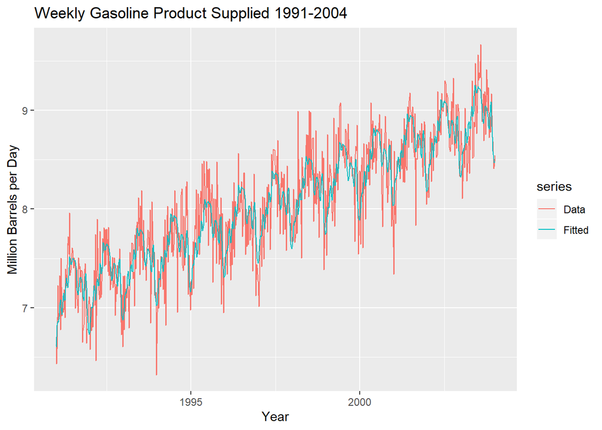

```r
autoplot(gasoline.data, series="Data") +
  autolayer(fitted(fourier.gasoline.k12), series="Fitted") +
  xlab("Year") + ylab("Million Barrels per Day") +
  ggtitle("Weekly Gasoline Product Supplied 1991-2004")
```

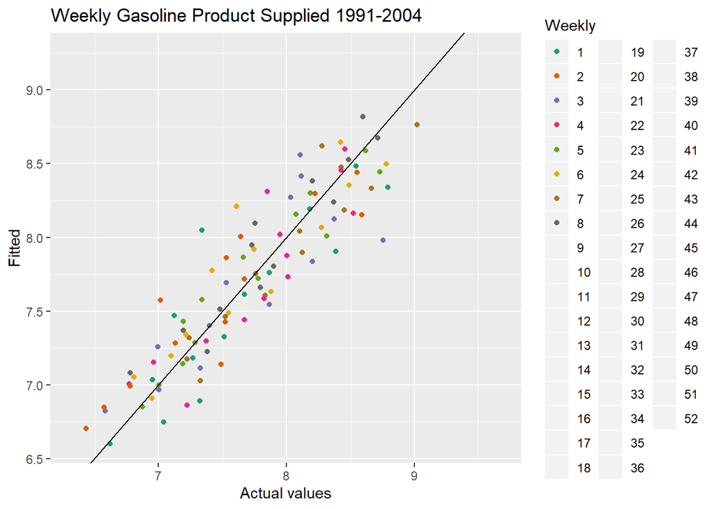

```r
cbind(Data=gasoline.data, Fitted=fitted(fourier.gasoline.k12)) %>%
  as.data.frame() %>%
  ggplot(aes(x = Data, y = Fitted,
             colour = as.factor(cycle(gasoline.data)))) +
    geom_point() +
    ylab("Fitted") + xlab("Actual values") +
    ggtitle("Weekly Gasoline Product Supplied 1991-2004") +
    scale_colour_brewer(palette="Dark2", name="Weekly") +
    geom_abline(intercept=0, slope=1)
```

### *b. Select the appropriate number of Fourier terms to include by minimising the AICc or CV value.*

The adjusted R^2 alone is not a good measure of the predictive ability of a model, so I will run the CV function on each tslm I’ve created:

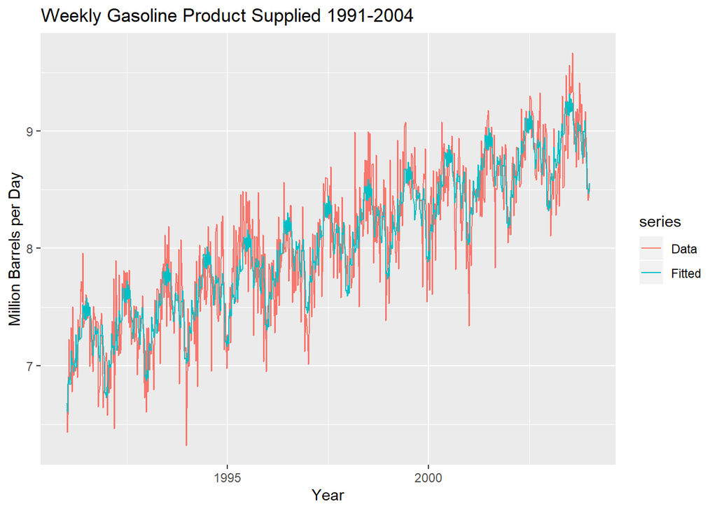

```r
fit.gasoline <- tslm(gasoline.data ~ trend + season)
autoplot(gasoline.data, series="Data") +
  autolayer(fitted(fit.gasoline), series="Fitted") +
  xlab("Year") + ylab("Million Barrels per Day") +
  ggtitle("Weekly Gasoline Product Supplied 1991-2004")
```

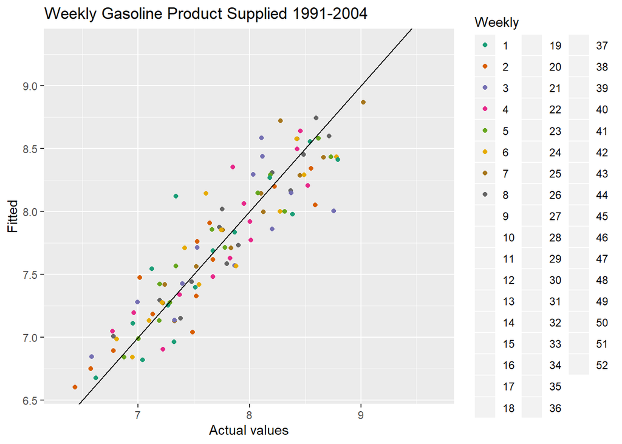

```r
cbind(Data=gasoline.data, Fitted=fitted(fit.gasoline)) %>%
  as.data.frame() %>%
  ggplot(aes(x = Data, y = Fitted,
             colour = as.factor(cycle(gasoline.data)))) +
    geom_point() +
    ylab("Fitted") + xlab("Actual values") +
    ggtitle("Weekly Gasoline Product Supplied 1991-2004") +
    scale_colour_brewer(palette="Dark2", name="Weekly") +
    geom_abline(intercept=0, slope=1)
```

```r
CV(fit.gasoline)
```

```
##            CV           AIC          AICc           BIC         AdjR2
##  8.054582e-02 -1.707412e+03 -1.697862e+03 -1.463458e+03  8.227727e-01
```

```r
CV(fourier.gasoline.k2)
```

```
##            CV           AIC          AICc           BIC         AdjR2
##  8.490968e-02 -1.667406e+03 -1.667238e+03 -1.635782e+03  7.991103e-01
```

```r
CV(fourier.gasoline.k3)
```

```
##            CV           AIC          AICc           BIC         AdjR2
##  8.056262e-02 -1.703014e+03 -1.702745e+03 -1.662355e+03  8.099600e-01
```

```r
CV(fourier.gasoline.k4)
```

```
##            CV           AIC          AICc           BIC         AdjR2
##  8.032276e-02 -1.705090e+03 -1.704693e+03 -1.655396e+03  8.110932e-01
```

```r
CV(fourier.gasoline.k5)
```

```
##            CV           AIC          AICc           BIC         AdjR2
##  7.956991e-02 -1.711519e+03 -1.710970e+03 -1.652789e+03  8.134213e-01
```

```r
CV(fourier.gasoline.k6)
```

```
##            CV           AIC          AICc           BIC         AdjR2
##  7.741155e-02 -1.730230e+03 -1.729503e+03 -1.662465e+03  8.190323e-01
```

```r
CV(fourier.gasoline.k7)
```

```
##            CV           AIC          AICc           BIC         AdjR2
##  7.686415e-02 -1.735129e+03 -1.734200e+03 -1.658329e+03  8.208552e-01
```

```r
CV(fourier.gasoline.k8)
```

```
##            CV           AIC          AICc           BIC         AdjR2
##  7.710447e-02 -1.733115e+03 -1.731958e+03 -1.647279e+03  8.208378e-01
```

```r
CV(fourier.gasoline.k9)
```

```
##            CV           AIC          AICc           BIC         AdjR2
##  7.741796e-02 -1.730477e+03 -1.729067e+03 -1.635606e+03  8.206537e-01
```

```r
CV(fourier.gasoline.k10)
```

```
##            CV           AIC          AICc           BIC         AdjR2
##     0.0775498 -1729.4479497 -1727.7572912 -1625.5415104     0.8208937
```

```r
CV(fourier.gasoline.k11)
```

```
##            CV           AIC          AICc           BIC         AdjR2
##  7.704117e-02 -1.734039e+03 -1.732042e+03 -1.621097e+03  8.226105e-01
```

```r
CV(fourier.gasoline.k12)
```

```
##            CV           AIC          AICc           BIC         AdjR2
##  7.709353e-02 -1.733745e+03 -1.731415e+03 -1.611768e+03  8.230369e-01
```

```r
CV(fourier.gasoline.k13)
```

```
##            CV           AIC          AICc           BIC         AdjR2
##     0.0774090 -1731.1368835 -1728.4475482 -1600.1244166     0.8228562
```

```r
CV(fourier.gasoline.k14)
```

```
##            CV           AIC          AICc           BIC         AdjR2
##  7.769731e-02 -1.728793e+03 -1.725717e+03 -1.588745e+03  8.227428e-01
```

```r
CV(fourier.gasoline.k15)
```

```
##            CV           AIC          AICc           BIC         AdjR2
##     0.0779507 -1726.7754533 -1723.2855622 -1577.6923013     0.8227130
```

```r
CV(fourier.gasoline.k16)
```

```
##            CV           AIC          AICc           BIC         AdjR2
##  7.833239e-02 -1.723677e+03 -1.719745e+03 -1.565558e+03  8.223981e-01
```

```r
CV(fourier.gasoline.k17)
```

```
##            CV           AIC          AICc           BIC         AdjR2
##  7.845439e-02 -1.722850e+03 -1.718449e+03 -1.555696e+03  8.226771e-01
```

```r
CV(fourier.gasoline.k18)
```

```
##            CV           AIC          AICc           BIC         AdjR2
##     0.0787924 -1720.1701565 -1715.2721973 -1543.9809768     0.8224687
```

```r
CV(fourier.gasoline.k19)
```

```
##            CV           AIC          AICc           BIC         AdjR2
##  7.925726e-02 -1.716427e+03 -1.711004e+03 -1.531203e+03  8.219789e-01
```

```r
CV(fourier.gasoline.k20)
```

```
##            CV           AIC          AICc           BIC         AdjR2
##  7.975031e-02 -1.712483e+03 -1.706505e+03 -1.518223e+03  8.214328e-01
```

```r
CV(fourier.gasoline.k21)
```

```
##            CV           AIC          AICc           BIC         AdjR2
##     0.0802233 -1708.7447943 -1702.1837801 -1505.4495870     0.8209380
```

```r
CV(fourier.gasoline.k22)
```

```
##            CV           AIC          AICc           BIC         AdjR2
##  8.061974e-02 -1.705692e+03 -1.698519e+03 -1.493361e+03  8.206216e-01
```

```r
CV(fourier.gasoline.k23)
```

```
##            CV           AIC          AICc           BIC         AdjR2
##  8.076443e-02 -1.704774e+03 -1.696959e+03 -1.483408e+03  8.208685e-01
```

```r
CV(fourier.gasoline.k24)
```

```
##            CV           AIC          AICc           BIC         AdjR2
##  8.109662e-02 -1.702307e+03 -1.693821e+03 -1.471906e+03  8.207036e-01
```

```r
CV(fourier.gasoline.k25)
```

```
##            CV           AIC          AICc           BIC         AdjR2
##  8.150646e-02 -1.699208e+03 -1.690020e+03 -1.459772e+03  8.203691e-01
```

```r
CV(fourier.gasoline.k26)
```

```
##            CV           AIC          AICc           BIC         AdjR2
##  8.054582e-02 -1.707412e+03 -1.697862e+03 -1.463458e+03  8.227727e-01
```

### *c. Check the residuals of the final model using the checkresiduals() function. Even though the residuals fail the correlation tests, the results are probably not severe enough to make much difference to the forecasts and prediction intervals. (Note that the correlations are relatively small, even though they are significant.)*

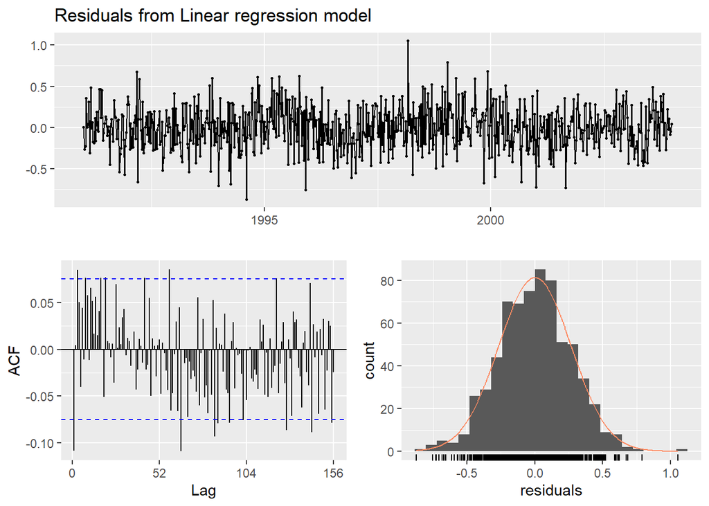

```
##
##  Breusch-Godfrey test for serial correlation of order up to 104
##
## data:  Residuals from Linear regression model
## LM test = 127.18, df = 104, p-value = 0.06099
```

```r
checkresiduals(fourier.gasoline.k13)
```

###*d. To forecast using harmonic regression, you will need to generate the future values of the Fourier terms.Forecast the next year of data.*

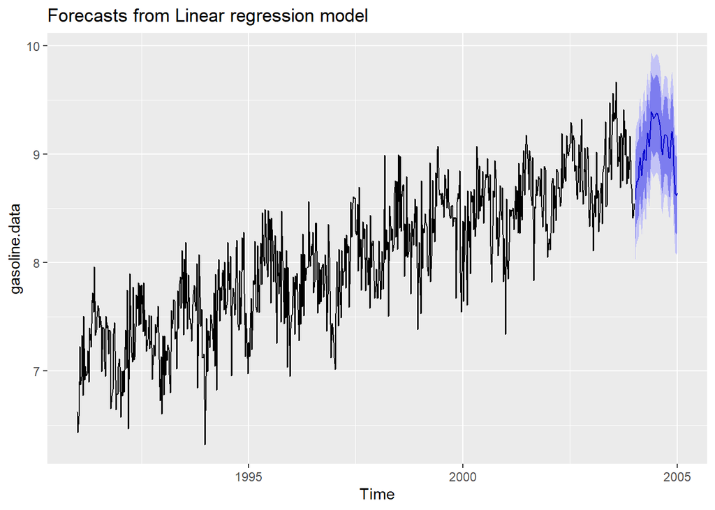

```r
fc <- forecast(fourier.gasoline.k13, newdata=data.frame(fourier(gasoline.data,13,52)))
autoplot(fc)
```

### *e. Plot the forecasts along with the actual data for 2005. What do you find?*

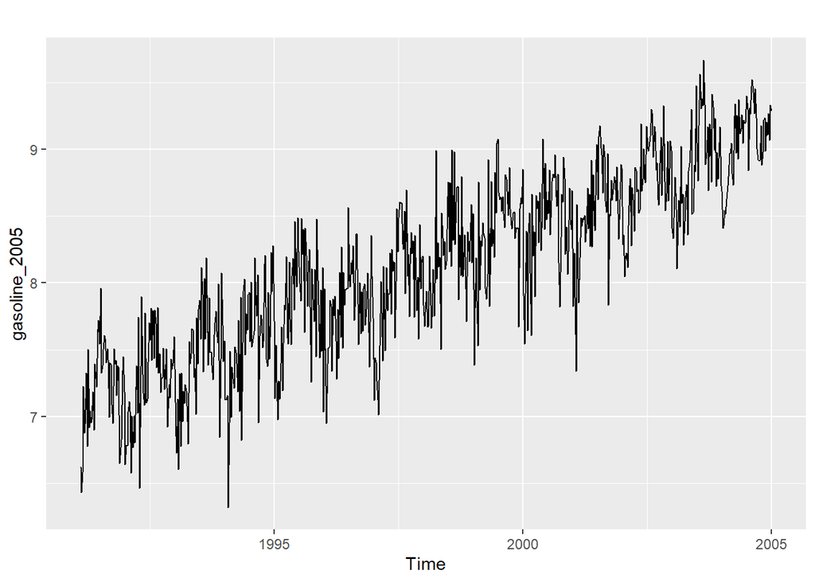

```r
gasoline_2005<-window(gasoline, end = 2005)
autoplot(gasoline_2005)
```

The forecast was pretty close, but the ending data point of 2005 was higher than predicted. The forecast did follow the general trend and accounted correctly for seasonality.

# We fitted a harmonic regression model to part of the gasoline series in Exercise 6 in Section 5.10. We will now revisit this model, and extend it to include more data and ARMA errors.

### *a. Using tslm(), fit a harmonic regression with a piecewise linear time trend to the full gasoline series. Select the position of the knots in the trend and the appropriate number of Fourier terms to include by minimising the AICc or CV value.*

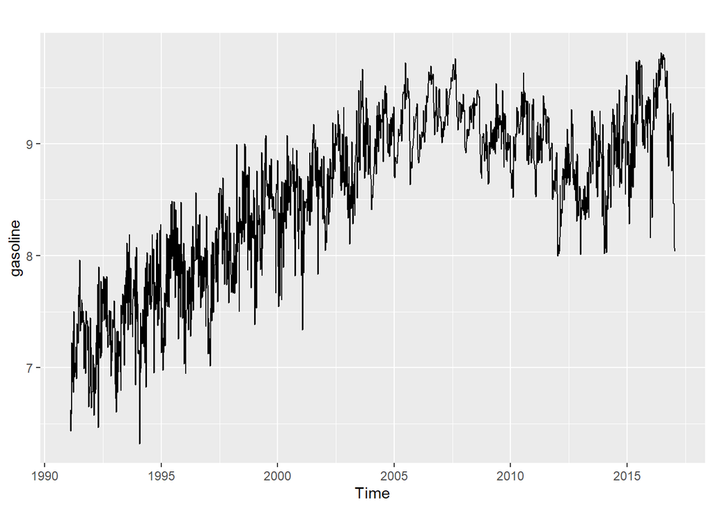

```r
autoplot(gasoline)
```

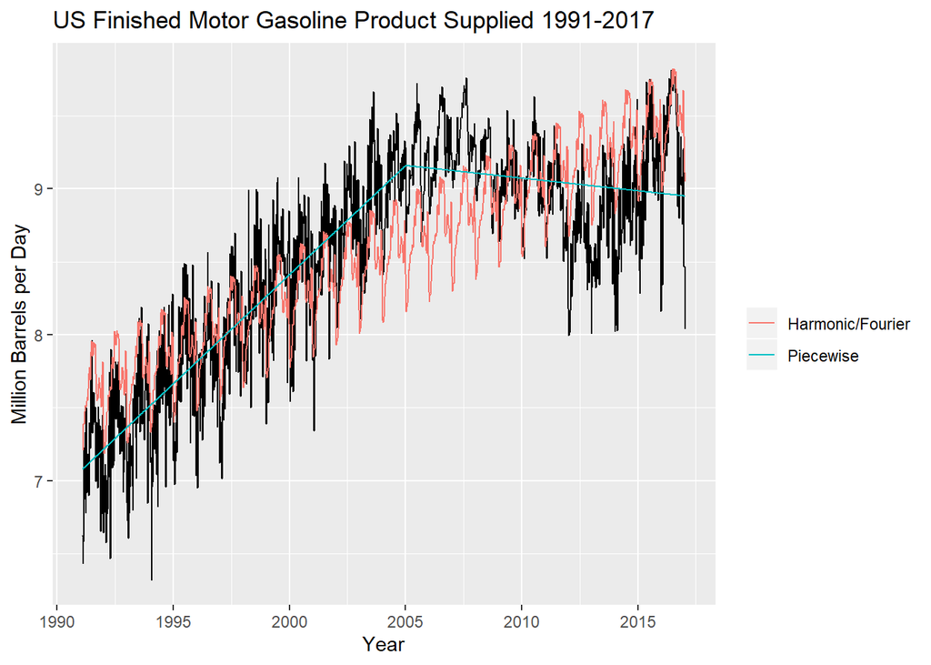

```r
gasoline.harmonic <- tslm(gasoline ~ trend + fourier(gasoline, K=13))

t <- time(gasoline)
t.break1 <- 1991
t.break2 <- 2005
tb1 <- ts(pmax(0, t - t.break1), start = 1991)
tb2 <- ts(pmax(0, t - t.break2), start = 1991)

fit.pw <- tslm(gasoline ~ t + tb1 + tb2)

autoplot(gasoline) +
  autolayer(fitted(gasoline.harmonic), series = "Harmonic/Fourier") +
  autolayer(fitted(fit.pw), series = "Piecewise") +
  xlab("Year") + ylab("Million Barrels per Day") +
  ggtitle("US Finished Motor Gasoline Product Supplied 1991-2017") +
  guides(colour = guide_legend(title = " "))
```

I decided to just move forward with the k value I used in the last exercise for my harmonic fit. For my piecewise fit, it appeared there was a constant linear upward trend from the beginning of the data until 2005. From then on the series apperad to plateau.

### *b. Now refit the model using auto.arima() to allow for correlated errors, keeping the same predictor variables as you used with tslm().*

```r
gasoline.auto <- auto.arima(gasoline) # Won't allow me to use 'trend' object past this point? Unable to add in my predictors
gasoline.auto
```

```
## Series: gasoline
## ARIMA(0,1,1)(1,0,0)[52]
##
## Coefficients:
##           ma1    sar1
##       -0.7440  0.2618
## s.e.   0.0206  0.0294
##
## sigma^2 estimated as 0.07239:  log likelihood=-144.86
## AIC=295.72   AICc=295.74   BIC=311.35
```

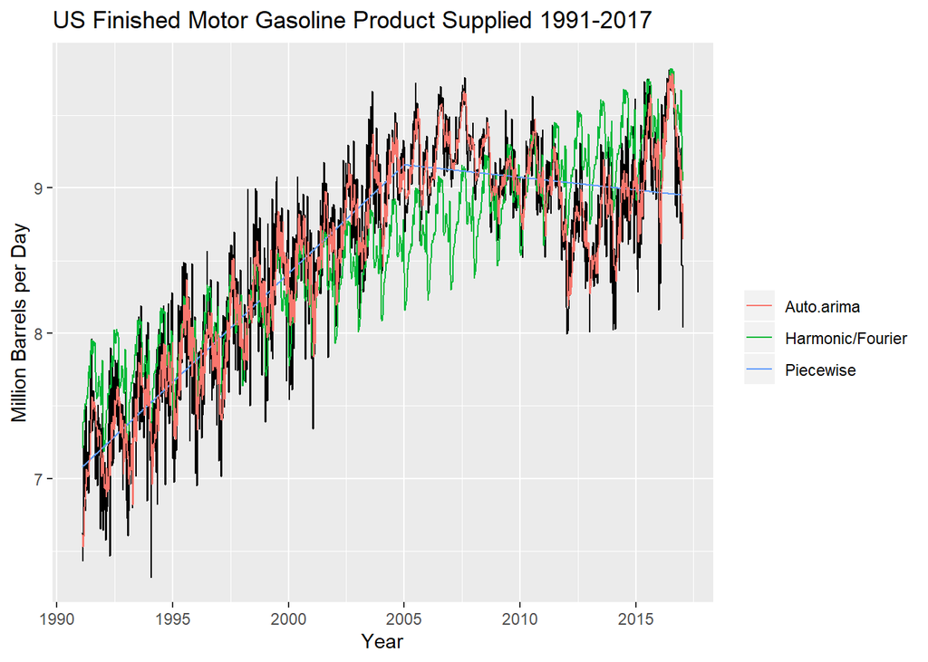

```r
autoplot(gasoline) +
  autolayer(fitted(gasoline.harmonic), series = "Harmonic/Fourier") +
  autolayer(fitted(fit.pw), series = "Piecewise") +
  autolayer(fitted(gasoline.auto), series = "Auto.arima") +
  xlab("Year") + ylab("Million Barrels per Day") +
  ggtitle("US Finished Motor Gasoline Product Supplied 1991-2017") +
  guides(colour = guide_legend(title = " "))
```

Based on the visualization alone I would move forward with my auto.arima fitted model, but I will cross examine against the residuals first.

### *c. Check the residuals of the final model using the checkresiduals() function. Do they look sufficiently like white noise to continue? If not, try modifying your model, or removing the first few years of data.*

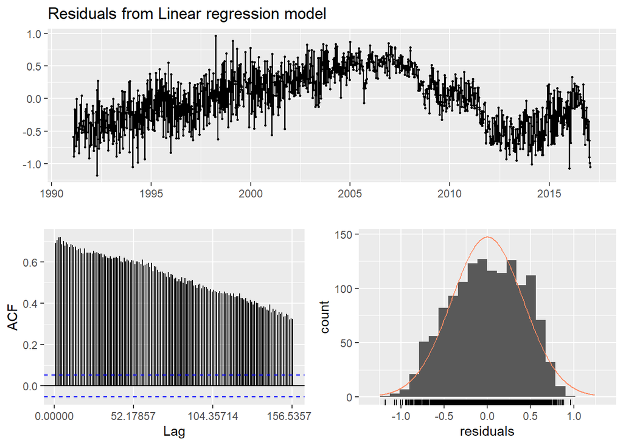

```
##
##  Breusch-Godfrey test for serial correlation of order up to 104
##
## data:  Residuals from Linear regression model
## LM test = 961.95, df = 104, p-value < 2.2e-16
```

```r
checkresiduals(gasoline.harmonic)
```

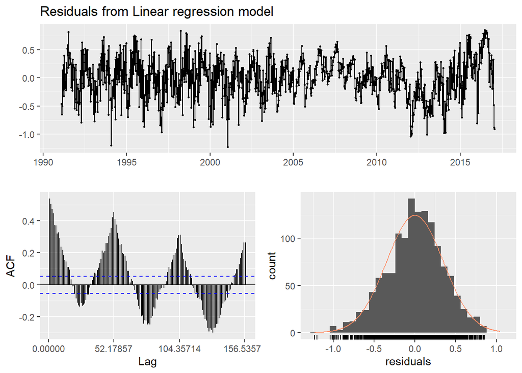

```
##
##  Breusch-Godfrey test for serial correlation of order up to 104
##
## data:  Residuals from Linear regression model
## LM test = 717.04, df = 104, p-value < 2.2e-16
```

```r
checkresiduals(fit.pw)
```

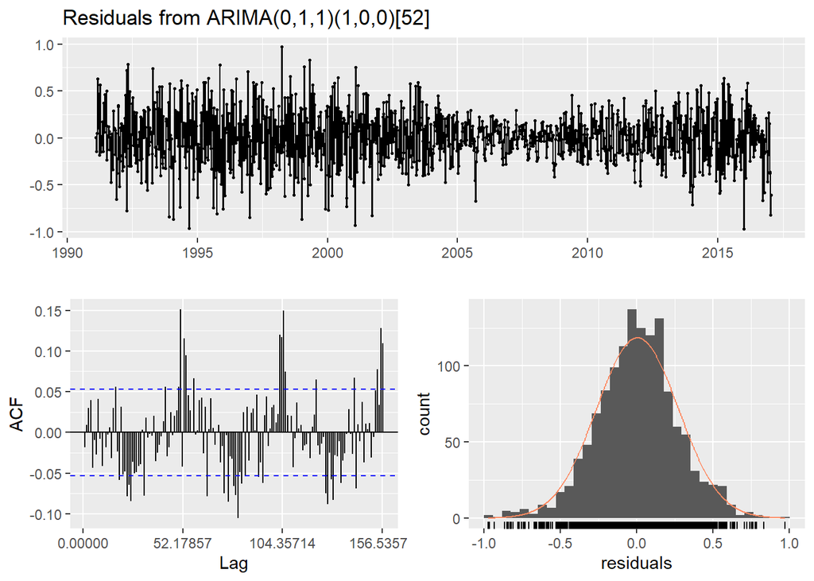

```
##
##  Ljung-Box test
##
## data:  Residuals from ARIMA(0,1,1)(1,0,0)[52]
## Q* = 330.24, df = 102.36, p-value < 2.2e-16
##
## Model df: 2.   Total lags used: 104.357142857143
```

```r
checkresiduals(gasoline.auto)
```

As I suspected my auto.arima performs the best out of my tested models. However, there is still a significant pattern in my acf plot so I will remove older data.

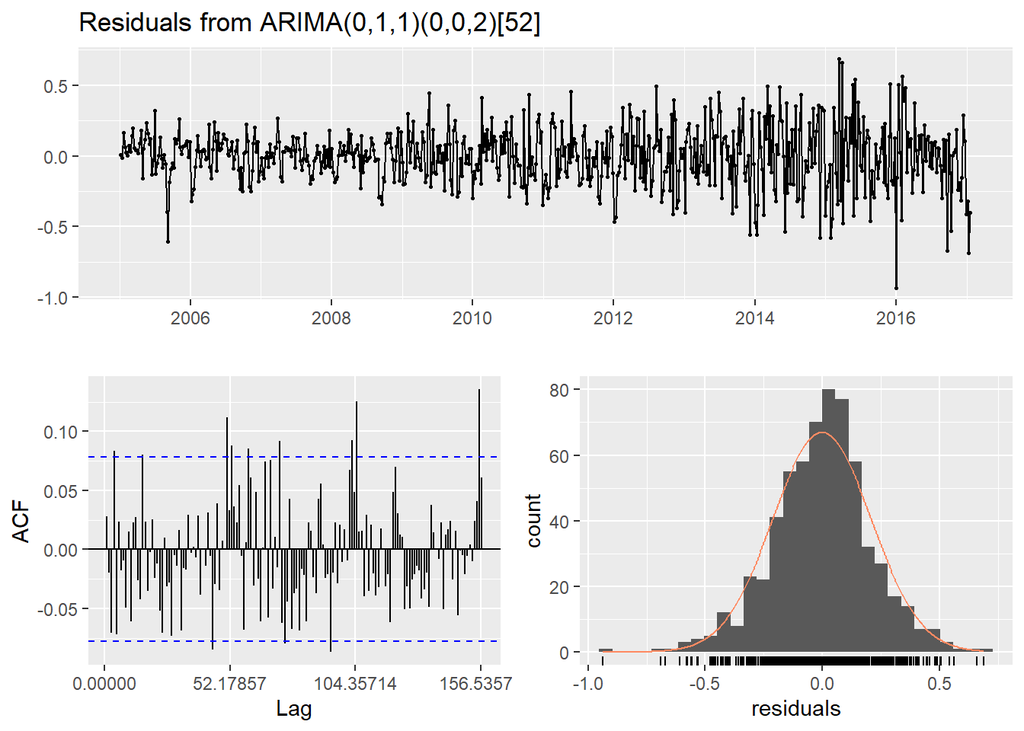

```
##
##  Ljung-Box test
##
## data:  Residuals from ARIMA(0,1,1)(0,0,2)[52]
## Q* = 148.15, df = 101.36, p-value = 0.001695
##
## Model df: 3.   Total lags used: 104.357142857143
```

```r
gasoline_post2005<-window(gasoline, start = 2005)
gasoline.auto<-auto.arima(gasoline_post2005)
checkresiduals(gasoline.auto)
```

Only analyzing 12 years of data brought my p value into a realistic range for analysis, and reduced the pattern I was seeing in my acf plot.

### *d. Once you have a model with white noise residuals, produce forecasts for the next year.*

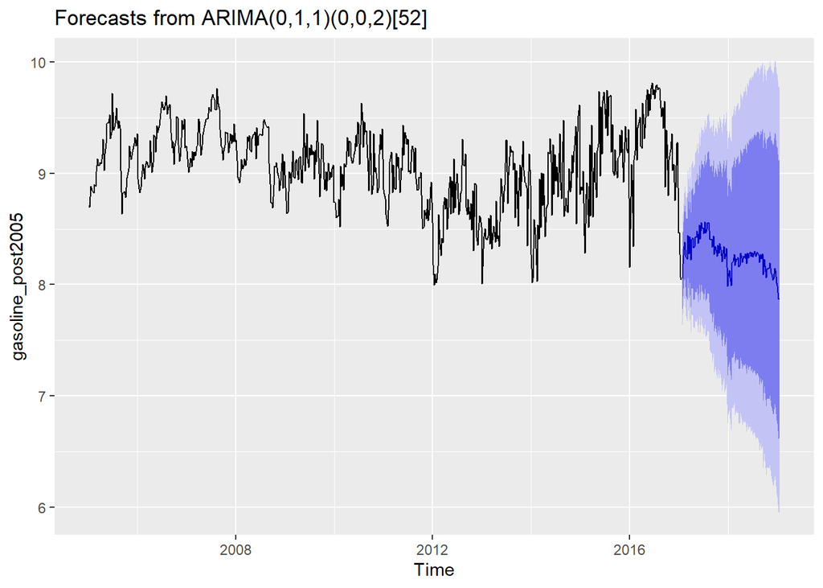

```r
autoplot(forecast(gasoline.auto), h=52)
```

I would argue that the forecast would capture the correct future values within the 95% CI, but I wouldn’t suggest using this model in practice. I would do further analysis with selection of predictors and would also experiment with including AR in my ARIMA or ARMA model, since auto.arima didn’t select an AR approach.